# R 統計解析

金城俊哉

> R統計解析パーフェクトマスター（R4完全対応）［統計&機械学習 第2版］ （単行本） 出版社URL: https://www.shuwasystem.co.jp/book/9784798067728.html

R Notebook File for my personal learning created by DS-SL.

1. Error in 8.4 2要因の分散分析②（2要因とも対応あり）
2. Error in 8.5 2要因の分散分析③（1要因のみ対応あり）

# 1 Rと統計学

## 1.1 データマイニングの時代だ

### 1.1.1 データマイニングをすると何がトクなの？

#### 1.1.1.1 データマイニングで成功をつかむ

#### 1.1.1.2 データマイニングと統計学

### 1.1.2 データマイニングのためのツール

#### 1.1.2.1 Rって言語？ それともツール？

#### 1.1.2.2 Rのイイところ

#### 1.1.2.3 Rにはプログラミングするからこそのよさがあります

## 1.2 RとRStudioをインストールしよう

### Memo Rのインストール（Macの場合）

### 1.2.1 Rをインストールし、続けてRStudioをインストールする

#### 1.2.1.1 Rのダウンロードとインストール

#### 1.2.1.2 Rを起動してみる

#### 1.2.1.3 RStudioのダウンロードとインストール

### Memo Macでのインストール手順

### 1.2.2 RStudioの起動と終了

#### 1.2.2.1 RStudioの起動

#### 1.2.2.2 RStudioの終了

### 1.2.3 RStudioの設定

#### 1.2.3.1 ホームディレクトリの設定

#### 1.2.3.2 作業ディレクトリの設定

# 2 R の基本（RStudioの操作と基本プログラミング）

## 2.1 RStudioでプログラムを実行する2つの方法（コンソールとソースファイル）

### 2.1.1 RStudioを関数電卓みたいに使う（コンソールを利用したプログラムの実行）

#### 2.1.1.1 計算を行うソースコードを入力してその場で結果（答え）を見る

#### 2.1.1.2 ソースコードは1文単位で実行

#### 2.1.1.3 処理結果は1行に収まらなければ複数の行にまたがって表示される

### 2.1.2 ソースファイルにコードを書いて実行する

### Memo ［History］ビュー

#### 2.1.2.1 ソースファイルの保存

#### 2.1.2.2 ソースファイルを開く

### 2.1.3 プロジェクトの作成

#### 2.1.3.1 プロジェクトを作成する

#### 2.1.3.2 プロジェクトを開く

## 2.2 Rの基本（データ操作）

### 2.2.1 Rでデータを扱うときは「変数（オブジェクト）」が基本

#### 2.2.1.1 とっておきたい値には名前を付けよう

#### 2.2.1.2 別の値に同じオブジェクト名を付ける

### 2.2.2 データのかたち（データ型）

#### 2.2.2.1 Rのデータ型は大きく分けて2つ

### 2.2.3 データ操作のキホン、ベクトルを使いこなそう

#### 2.2.3.1 ベクトルの作成

#### 2.2.3.2 ベクトル要素の取り出しと置き換え

#### 2.2.3.3 ベクトルの結合と挿入

#### 2.2.3.4 ベクトルの要素に名前を付ける

#### 2.2.3.5 ベクトル同士の演算

```r
a <- 50 + 50
a
```

```
[1] 100
```

```r
b <- a
a
```

```
[1] 100
```

```r
b
```

```
[1] 100
```

```r
a <- 5
a
```

```
[1] 5
```

```r
b
```

```
[1] 100
```

```r
a <- 1
mode(a)
```

```
[1] "numeric"
```

```r
storage.mode(a)
```

```
[1] "double"
```

```r
class(a)
```

```
[1] "numeric"
```

```r
name <- "秀和太郎"
name
```

```
[1] "秀和太郎"
```

```r
# 数値型のベクトル
n1 <- c(2, 3, 4)
n1
```

```
[1] 2 3 4
```

```r
# 文字列型のベクトル
chr1 <- c("おはよう", "こんにちは", "わんばんこ")
chr1
```

```
[1] "おはよう"   "こんにちは" "わんばんこ"
```

```r
# ベクトルを削除する
rm(n1)
rm(chr1)
```

```r
n1
```

```r
chr1
```

```r
# ベクトルの長さ
x <- c(10, 20, 30, 40, 50)
length(x)
```

```
[1] 5
```

```r
# 要素の取り出し
vec <- c(10, 20)
vec
```

```
[1] 10 20
```

```r
vec[1]
```

```
[1] 10
```

```r
vec[2]
```

```
[1] 20
```

```r
vec[3]
```

```
[1] NA
```

```r
x <- c(10, 20, 30, 40, 50)
x[2:4]
```

```
[1] 20 30 40
```

```r
x[c(1, 3, 5)]
```

```
[1] 10 30 50
```

```r
x[-1]
```

```
[1] 20 30 40 50
```

```r
x[c(-1, -3, -5)]
```

```
[1] 20 40
```

```r
x[30 < x]
```

```
[1] 40 50
```

```r
x[30 > x]
```

```
[1] 10 20
```

```r
x[10 < x & 40 > x]
```

```
[1] 20 30
```

```r
# 要素の置き換え
x[5] <- 0
x
```

```
[1] 10 20 30 40  0
```

```r
x[5] <- "hello"
x
```

```
[1] "10"    "20"    "30"    "40"    "hello"
```

```r
# ベクトルの結合
x <- c(1, 2, 3); y <- c(4, 5, 6); z <- c(7, 8, 9)
a <- c(x, y, z)
a
```

```
[1] 1 2 3 4 5 6 7 8 9
```

```r
b <- append(x, y)
b
```

```
[1] 1 2 3 4 5 6
```

```r
c <- append(b, y, after=3)
c
```

```
[1] 1 2 3 4 5 6 4 5 6
```

```r
# ベクトルの要素に名前を付ける
num <- c(1, 2, 3, 4, 5, 6)
names(num) <- c("one", "two", "three", "four", "five", "six")
num
```

```
  one   two three  four  five   six
    1     2     3     4     5     6
```

```r
names(num)
```

```
[1] "one"   "two"   "three" "four"  "five"  "six"
```

```r
num["one"]
```

```
one
  1
```

```r
# 名前属性の操作
names(num) <- c("num1", "num2", "num3", "num4", "num5", "num6")
num
```

```
num1 num2 num3 num4 num5 num6
   1    2    3    4    5    6
```

```r
names(num) <- NULL
num
```

```
[1] 1 2 3 4 5 6
```

```r
# ベクトルの演算
x <- c(1, 2, 3); y <- c(1, 2, 3)
z <- x + y
z
```

```
[1] 2 4 6
```

```r
z <- x * y
z
```

```
[1] 1 4 9
```

```r
x <- c(100, 100, 200, 200); y <- c(0.1, 1.1)
z <- x * y
z
```

```
[1]  10 110  20 220
```

```r
price <- c(1000, 2000, 3000)
tax_in <- price * 1.1
tax_in
```

```
[1] 1100 2200 3300
```

```r
# 規則性のあるベクトルの作成
x <- 1:5
x
```

```
[1] 1 2 3 4 5
```

```r
y <- 5:-5
y
```

```
 [1]  5  4  3  2  1  0 -1 -2 -3 -4 -5
```

```r
a <- rep(1:3, length=9)
a
```

```
[1] 1 2 3 1 2 3 1 2 3
```

```r
# データ型を調べる
chr <- "R"
is.numeric(chr)
```

```
[1] FALSE
```

```r
is.character(chr)
```

```
[1] TRUE
```

```r
# データ型の変換
data1 <- c("1.23", "20.34", "300.45")
mode(data1)
```

```
[1] "character"
```

```r
conv1 <- as.numeric(data1)
mode(conv1)
```

```
[1] "numeric"
```

```r
storage.mode(conv1)
```

```
[1] "double"
```

```r
conv1
```

```
[1]   1.23  20.34 300.45
```

```r
conv1 <- as.integer(conv1)
mode(conv1)
```

```
[1] "numeric"
```

```r
storage.mode(conv1)
```

```
[1] "integer"
```

```r
conv1
```

```
[1]   1  20 300
```

### Memo 規則性のあるベクトルの作成

### Hint データ型が何かを調べる

### 2.2.4 データ型の変換

#### 2.2.4.1 関数を使ってデータ型を変換する

### 2.2.5 リスト

#### 2.2.5.1 リストの要素を取り出す

#### 2.2.5.2 リスト要素のベクトルの要素を取り出す

#### 2.2.5.3 リスト要素を「名前＝値」のペアで管理する

```r
# リストの作成---------------------------------
# 顧客のidをベクトルに格納
id <- c(101, 102, 103)
# 顧客名をベクトルに格納
name <- c("秀和太郎",
          "秀和花子",
          "宗田解析")
# 住所をベクトルに格納
address <- c("東京都江東区東陽2",
            "東京都江東区東陽2-4",
            "東京都中央区銀座100")
# 顧客情報をまとめたリストを作成
customer <- list(id, name, address)
# customerの構造を出力
str(customer)
```

```
List of 3
 $ : num [1:3] 101 102 103
 $ : chr [1:3] "秀和太郎" "秀和花子" "宗田解析"
 $ : chr [1:3] "東京都江東区東陽2" "東京都江東区東陽2-4" "東京都中央区銀座100"
```

```r
# リストの要素をリストとして取得
list1 <- customer[1] # リストの第1要素を取得
list2 <- customer[2] # リストの第2要素を取得
list3 <- customer[3] # リストの第3要素を取得
# 出力
list1
```

```
[[1]]
[1] 101 102 103
```

```r
list2
```

```
[[1]]
[1] "秀和太郎" "秀和花子" "宗田解析"
```

```r
list3
```

```
[[1]]
[1] "東京都江東区東陽2"   "東京都江東区東陽2-4" "東京都中央区銀座100"
```

```r
class(list1)
```

```
[1] "list"
```

```r
class(list2)
```

```
[1] "list"
```

```r
class(list3)
```

```
[1] "list"
```

```r
# リストの要素を取得
element1 <- customer[[1]] # リストの第1要素を取得
element2 <- customer[[2]] # リストの第2要素を取得
element3 <- customer[[3]] # リストの第3要素を取得
# 出力
element1
```

```
[1] 101 102 103
```

```r
element2
```

```
[1] "秀和太郎" "秀和花子" "宗田解析"
```

```r
element3
```

```
[1] "東京都江東区東陽2"   "東京都江東区東陽2-4" "東京都中央区銀座100"
```

```r
class(element1)
```

```
[1] "numeric"
```

```r
class(element2)
```

```
[1] "character"
```

```r
class(element3)
```

```
[1] "character"
```

```r
# リストの第1要素のベクトルから第1要素を取り出す
vector1_2 <- customer[[1]][1]
vector1_2
```

```
[1] 101
```

```r
class(vector1_2)
```

```
[1] "numeric"
```

```r
# リスト要素のベクトルの要素を取り出す
id_1 <- customer[[1]][1]     # 一人目のid
name_1 <- customer[[2]][[1]] # 一人目の名前
addr_1 <- customer[[3]][[1]] # 一人目の住所
# データ型と値を出力
str(id_1)
```

```
 num 101
```

```r
str(name_1)
```

```
 chr "秀和太郎"
```

```r
str(addr_1)
```

```
 chr "東京都江東区東陽2"
```

```r
# customerの第1要素を変更する
customer[[1]] <- c(1, 2, 3)
# 出力
customer
```

```
[[1]]
[1] 1 2 3

[[2]]
[1] "秀和太郎" "秀和花子" "宗田解析"

[[3]]
[1] "東京都江東区東陽2"   "東京都江東区東陽2-4" "東京都中央区銀座100"
```

```r
# customerの第1要素のベクトルの第3要素を変更する
customer[[1]][3] <- 333
# 出力
customer
```

```
[[1]]
[1]   1   2 333

[[2]]
[1] "秀和太郎" "秀和花子" "宗田解析"

[[3]]
[1] "東京都江東区東陽2"   "東京都江東区東陽2-4" "東京都中央区銀座100"
```

```r
# リストの要素に名前を付ける
customer <- list(
  id = c(101, 102, 103),
  name = c("秀和太郎",
           "秀和花子",
           "宗田解析"),
  address = c("東京都江東区東陽2",
              "東京都江東区東陽2-4",
              "東京都中央区銀座100")
  )
# リストを出力
customer
```

```
$id
[1] 101 102 103

$name
[1] "秀和太郎" "秀和花子" "宗田解析"

$address
[1] "東京都江東区東陽2"   "東京都江東区東陽2-4" "東京都中央区銀座100"
```

```r
# リスト["要素名"]でリストとして取り出す
customer["id"]
```

```
$id
[1] 101 102 103
```

```r
# リスト[["要素名"]]で要素を取り出す
customer[["id"]]
```

```
[1] 101 102 103
```

```r
# idの第1要素を取り出す
customer[["id"]][1]
```

```
[1] 101
```

```r
# リスト$要素名とすると要素が取り出される
customer$id
```

```
[1] 101 102 103
```

```r
# idの第1要素を取り出す
customer$id[1]
```

```
[1] 101
```

### 2.2.6 行列（マトリックス）

#### 2.2.6.1 行列は（行，列）の集計表

### Hint 配列

```r
# ベクトルを用意
vct1 <- c(1, 2, 3, 4, 5, 6)
vct2 <- c(10, 20, 30, 40, 50, 60)
vct3 <- c(100, 200, 300, 400, 500, 600)
# (3行,2列)の行列を3個作成
mtx1 <- matrix(c(1, 2, 3, 4, 5, 6), ncol=2)
mtx2 <- matrix(c(10, 20, 30, 40, 50, 60), ncol=2)
mtx3 <- matrix(c(100, 200, 300, 400, 500, 600), ncol=2)
array1 <- array(
  c(mtx1, mtx2, mtx3), # vct1、vct2、vct3を1つのベクトルにする
  dim=c(3,2,3)         # 行数3、列数2、行列の数3を指定
)
# 配列の中身を出力
array1
```

```
, , 1

     [,1] [,2]
[1,]    1    4
[2,]    2    5
[3,]    3    6

, , 2

     [,1] [,2]
[1,]   10   40
[2,]   20   50
[3,]   30   60

, , 3

     [,1] [,2]
[1,]  100  400
[2,]  200  500
[3,]  300  600
```

```r
# 3次元のインデックスのみを指定して1つ目の行列を抽出
array1[, , 1]
```

```
     [,1] [,2]
[1,]    1    4
[2,]    2    5
[3,]    3    6
```

```r
# ベクトルを用意する
vct1 <- c(1, 2, 3, 4, 5, 6)
vct2 <- c(10, 20, 30, 40, 50, 60)
vct3 <- c(100, 200, 300, 400, 500, 600)

mtx1 <- matrix(vct1)             # 行列(縦ベクトル)を作成
mtx1                             # 出力
```

```
     [,1]
[1,]    1
[2,]    2
[3,]    3
[4,]    4
[5,]    5
[6,]    6
```

```r
mtx2 <- matrix(vct1, nrow=2)     # 2行の行列を作成
mtx2                             # 出力
```

```
     [,1] [,2] [,3]
[1,]    1    3    5
[2,]    2    4    6
```

```r
mtx3 <- matrix(vct1, ncol=2)     # 2列の行列を作成
mtx3                             # 出力
```

```
     [,1] [,2]
[1,]    1    4
[2,]    2    5
[3,]    3    6
```

```r
mtx4 <- matrix(vct1, 2,2)        # (2行,2列)の行列を作成
mtx4                             # 出力
```

```
     [,1] [,2]
[1,]    1    3
[2,]    2    4
```

```r
mtx5 <- matrix(
  c(vct1, vct2, vct3), # vct1, vct2, vct3を1つのベクトルにする
  nrow=3,              # 2行の行列
  byrow = TRUE)        # 値を行方向に並べる
mtx5                   # 出力
```

```
     [,1] [,2] [,3] [,4] [,5] [,6]
[1,]    1    2    3    4    5    6
[2,]   10   20   30   40   50   60
[3,]  100  200  300  400  500  600
```

```r
mtx6 <- rbind(vct1, vct2, vct3)  # 3つのベクトルを行方向に連結する
mtx6                             # 出力
```

```
     [,1] [,2] [,3] [,4] [,5] [,6]
vct1    1    2    3    4    5    6
vct2   10   20   30   40   50   60
vct3  100  200  300  400  500  600
```

```r
colSums(mtx6)                    # 列の合計を求める
```

```
[1] 111 222 333 444 555 666
```

```r
rowSums(mtx6)                    # 行の合計を求める
```

```
vct1 vct2 vct3
  21  210 2100
```

```r
mtx7 <- cbind(vct1, vct2, vct3)  # 3つのベクトルを列方向に連結する
mtx7                             # 出力
```

```
     vct1 vct2 vct3
[1,]    1   10  100
[2,]    2   20  200
[3,]    3   30  300
[4,]    4   40  400
[5,]    5   50  500
[6,]    6   60  600
```

```r
mtx7[1,]   # 1行目を取り出す
```

```
vct1 vct2 vct3
   1   10  100
```

```r
mtx7[,1]   # 1列目を取り出す
```

```
[1] 1 2 3 4 5 6
```

```r
mtx7[1,1]  # 1行目の1列目の値を取り出す
```

```
vct1
   1
```

### 2.2.7 データフレーム

#### 2.2.7.1 データフレームの作成

```r
# 店舗名を格納したベクトル
branch <- c(
  "初台店", "幡谷店", "吉祥寺店", "笹塚店", "明大前店")
# 各店舗の売上額(千円)を格納したベクトル
sales <- c(2024, 2164, 6465, 2186, 2348)
# データフレームを作成
df <- data.frame(branch=branch, # 列1
                 salses=sales)  # 列2

df$branch # 列データを要素として取り出す
```

```
[1] "初台店"   "幡谷店"   "吉祥寺店" "笹塚店"   "明大前店"
```

```r
df[[1]]   # 列データを要素として取り出す
```

```
[1] "初台店"   "幡谷店"   "吉祥寺店" "笹塚店"   "明大前店"
```

```r
df[,1]    # 列データを要素として取り出す
```

```
[1] "初台店"   "幡谷店"   "吉祥寺店" "笹塚店"   "明大前店"
```

```r
df[1]     # 列データをデータフレームとして取り出す
```

| branch |
| --- |
| 初台店 |
| 幡谷店 |
| 吉祥寺店 |
| 笹塚店 |
| 明大前店 |

```r
df[1:2]   # 指定した範囲の列をデータフレームとして取り出す
```

| branch | salses |
| --- | --- |
| 初台店 | 2024 |
| 幡谷店 | 2164 |
| 吉祥寺店 | 6465 |
| 笹塚店 | 2186 |
| 明大前店 | 2348 |

```r
df[1,]    # 行データをデータフレームとして取り出す
```

|  | branch | salses |
| --- | --- | --- |
| 1 | 初台店 | 2024 |

```r
df[1:3,]  # 指定した範囲の行をデータフレームとして取り出す
```

|  | branch | salses |
| --- | --- | --- |
| 1 | 初台店 | 2024 |
| 2 | 幡谷店 | 2164 |
| 3 | 吉祥寺店 | 6465 |

```r
df[1,1]   # 特定の要素を取り出す
```

```
[1] "初台店"
```

### Memo コメントについて

#### 2.2.7.2 データフレームから列や行のデータを取り出す

#### 2.2.7.3 外部ファイルのデータをデータフレームに取り込む

#### 2.2.7.4 タブ区切りのテキストファイルをデータフレームに読み込んでみよう

```r
# タブ区切りの店舗別売上.txtをデータフレームに読み込む
data <- read.table(
  "data/店舗別売上.txt",    # ファイル名
  header=TRUE,         # 1行目は列名であることを指定
  fileEncoding="UTF-8" # 文字コードをUTF-8に指定
)
data
```

| 店舗名 | 売上高_千円 |
| --- | --- |
| 初台店 | 2024 |
| 幡谷店 | 2164 |
| 吉祥寺店 | 6465 |
| 笹塚店 | 2186 |
| 明大前店 | 2348 |
| 下高井戸店 | 1981 |
| 桜上水店 | 2256 |
| 千歳烏山店 | 3177 |
| 仙川店 | 1861 |
| 下高井戸店 | 3249 |

[output cut: 10 more lines]

### Tips Excelのデータをクリップボード経由で読み込む

Don’t run the following code.

```r
# クリップボードにコピーしたデータをデータフレームに読み込む
data <- read.table("clipboard", # ファイル名を"clipboard"にする
                   header=TRUE) # データの1行目を列名として設定
```

The above code does not work for Mac and probably for Linux using X11. Use the following.

```r
data <- read_delim(clipboard())
data
```

## 2.3 プログラムの制御と関数（制御構造と関数）

### 2.3.1 「もしも」で処理を分ける（ifステートメント）

#### 2.3.1.1 ifステートメントの書き方

```r
# numに負の値を代入
num <- -10

if(num < 0){
  # numが負の値であれば-1を掛けて正の値にする
  num <- num * -1
}

# numの値を出力
num
```

```
[1] 10
```

#### 2.3.1.2 「そうでなければ」を実行するelse if／else

```r
# numに正の値を代入
num <- 10

if(num < 0) {
  # numが負の値なら-1を掛けて正の値にする
  num <- num * -1
} else if(num > 0) {
  # numが正の値なら-1を掛けて負の値にする
  num <- num * -1
}

# numの値を出力
num
```

```
[1] -10
```

```r
# numに文字列を代入
val <- "-10"
if(is.numeric(val) & val < 0){
  # valが実数型かつ負の値なら-1を掛けて正の値にする
  n <- n * -1
} else if (is.numeric(val) & val > 0) {
  # nvalは実数型かつ正の値なら-1を掛けて負の値にする
  val <- val * -1
} else {
  # どの条件も成立しない場合はnumeric型に変換する
  val <- as.numeric(val)
}

# valの情報を出力
str(val)
```

```
 num -10
```

### 2.3.2 同じ処理を繰り返す（forステートメント）

#### 2.3.2.1 指定した回数だけ処理を繰り返す

```r
# 定着度.txtをデータフレームに読み込む
data <- read.table(
  "data/定着度.txt",
  header=T,            # 1行目は列名
  fileEncoding="UTF-8" # 文字コードはUTF-8
)

# データフレームの1行目(列名の次行)を指定して
# 列の数を調べる(4列)
j <- length(data[1,])

# イテレート可能なオブジェクトc(1:j)で1列～4列を順に処理
for(i in c(1:j)) {
  # 連番を付けたオブジェクトを生成して列データを代入
  assign(
    sprintf("x%d", i), # ベクトル名はx1、x2、x3、x4
    data[,i]           # データフレームの1列目から代入
  )
}
```

```r
data
```

| 受講生 | 講義中心コース | 演習中心コース | 暗記集中コース |
| --- | --- | --- | --- |
| A | 66 | 56 | 37 |
| B | 70 | 55 | 45 |
| C | 52 | 48 | 54 |
| D | 55 | 55 | 50 |
| E | 73 | 60 | 62 |
| F | 62 | 62 | 54 |
| G | 75 | 40 | 60 |

### 2.3.3 決まった処理に名前を付けて呼び出せるようにしよう（関数の作成）

#### 2.3.3.1 処理だけを行う関数

```r
# 処理だけを行う関数
show <- function() {
  print("Hello!")
}
# 関数を呼び出す
show()
```

```
[1] "Hello!"
```

#### 2.3.3.2 引数を受け取る関数

```r
# パラメーターが設定された関数
showParameter <- function(word_1, word_2) {
  print(word_1) # word_1を出力
  print(word_2) # word_2を出力
}

# 引数を指定して関数を呼び出す
showParameter("Rの世界へ", "ようこそ！")
```

```
[1] "Rの世界へ"
[1] "ようこそ！"
```

#### 2.3.3.3 戻り値を返す関数

```r
# 引数を受け取って戻り値を返す関数
calculateTax <- function(val) {
  tax_in <- val * 1.1 # valに1.1を掛ける
  return(tax_in)      # tax_inを戻り値として返す
}

# 引数を指定して関数を呼び出す
calculateTax(100)
```

```
[1] 110
```

#### 2.3.3.4 作成した関数を他のソースファイルから実行できるようにしよう

```r
# タブ区切りのテキストファイルをデータフレームに読み込む関数
# Parameter:
#   path: ファイル名またはファイルパス
load.file <- function(path) {
  # ファイルを読み込んでデータフレームに格納
  data <- read.table(
    path,                # 読み込むファイル
    header=T,            # 1行目は列名を指定
    fileEncoding="UTF-8" # 文字コードをUTF-8に指定
  )
  # データフレームを戻り値として返す
  return(data)
}
```

```r
# load-file.Rを読み込む
source("data/load-file.R", encoding="utf-8")

# ファイル名を引数にしてload.file()関数を呼び出す
data <- load.file("data/店舗別売上.txt")
```

```r
data
```

| 店舗名 | 売上高_千円 |
| --- | --- |
| 初台店 | 2024 |
| 幡谷店 | 2164 |
| 吉祥寺店 | 6465 |
| 笹塚店 | 2186 |
| 明大前店 | 2348 |
| 下高井戸店 | 1981 |
| 桜上水店 | 2256 |
| 千歳烏山店 | 3177 |
| 仙川店 | 1861 |
| 下高井戸店 | 3249 |

[output cut: 10 more lines]

### Memo RStudio

# 3 データの全体像を解析する（代表値）

## 3.1 データをならして出てくる代表値（平均）

### 3.1.1 平均を求める

```r
# access.csvをデータフレームに読み込む
df <- read.csv("data/access.csv", encoding = "UTF-8")

# アクセス数の平均を求める
access_mean <- mean(df$アクセス数)
# 出力
access_mean
```

```
[1] 347.3667
```

#### 3.1.1.1 平均値を求める式

## 3.2 データの分布を棒グラフで見やすくしよう（ヒストグラム）

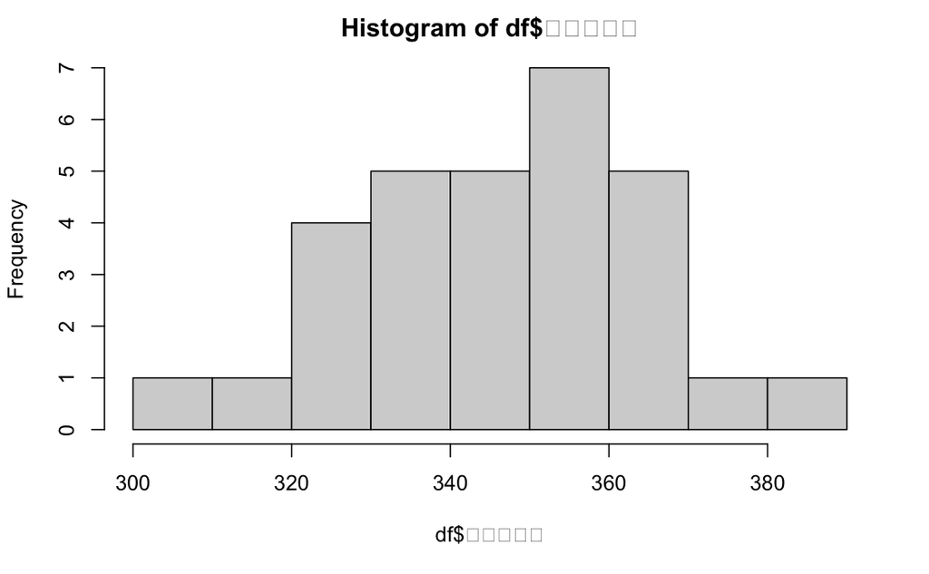

```r
# access.csvを読み込んでデータフレームに格納
df <- read.csv("data/access.csv", encoding="UTF-8")
# 階級を自動で設定してヒストグラムを作成
hist(df$アクセス数)  # "アクセス数"の列を対象にする
```

#### 3.2.1.1 ヒストグラムは「階級の幅」を決めて「階級」を作る

## 3.3 階級幅を独自に指定したヒストグラムを作る

### 3.3.1 階級幅や棒グラフの色を指定してヒストグラムを作成する

#### 3.3.1.1 最小値と最大値を調べてヒストグラムの下限値と上限値を決定する（手順①～②）

#### 3.3.1.2 ヒストグラムの作成（手順③）

#### 3.3.1.3 コードを入力してヒストグラムを作成してみる

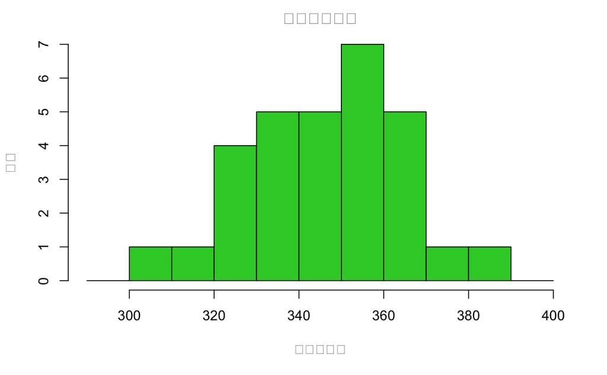

```r
# access.csvをデータフレームに格納
df <- read.csv("data/access.csv", encoding="UTF-8")

# 階級の幅
w <- 10
# アクセス数の最小値、最大値を求める
fnum <- fivenum(df$アクセス数)
# 最小値の上位2桁で丸め、階級幅×2を引く
min <- signif(fnum[1], 2) - (w*2)
# 最大値に階級の幅×2を加える
max <- fnum[5] + (w*2)

# アクセス数のヒストグラムを作成
hist(
  # データフレームのアクセス数の列を指定
  df$アクセス数,
  # ヒストグラムの下限値、上限値、階級の幅をベクトルで指定
  breaks = seq(min, max, by = w),
  # タイトルを設定
  main = "アクセス状況",
  # 横軸のラベル
  xlab = "アクセス数",
  # 縦軸のラベル
  ylab = "頻度",
  # 棒グラフの色を設定
  col="limegreen")
```

### Memo 階級の幅

#### 3.3.1.4 ヒストグラムの山は1つか2つ以上か

## 3.4 度数分布表から相対度数分布表を作る

### 3.4.1 相対度数分布表を作る

#### 3.4.1.1 度数分布表を作成し、これをもとに相対度数分布表を作成する

#### 3.4.1.2 相対度数を棒グラフにしてみる

#### 3.4.1.3 相対度数分布表を作成する関数を定義する

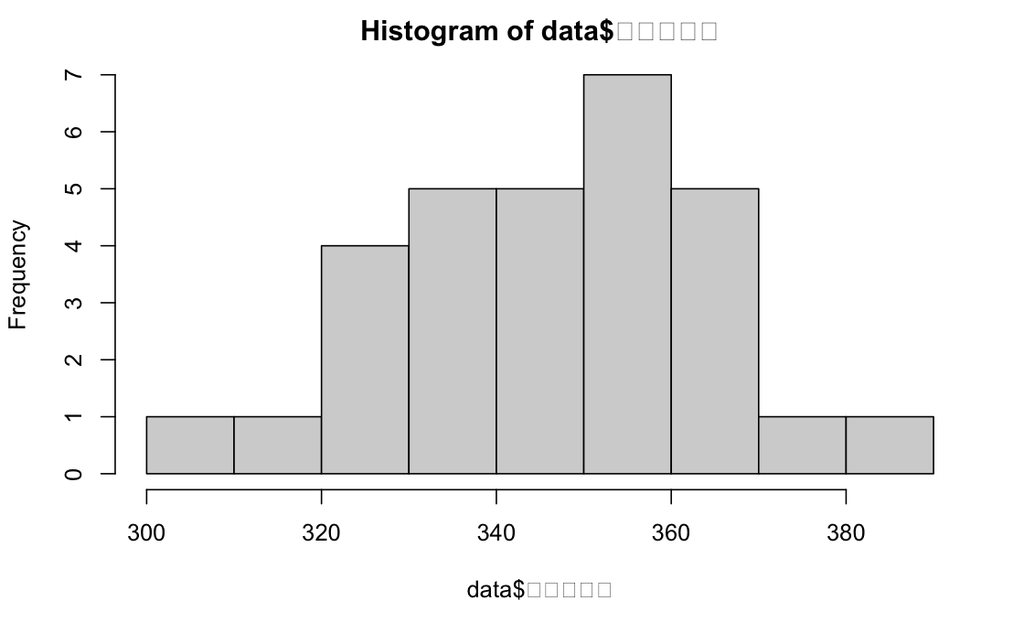

```r
# access.csvをデータフレームとしてdataに代入
data <- read.csv("data/access.csv", encoding="UTF-8")
# ヒストグラムを作成し、hist()の戻り値をhstに代入
hst <- hist(data$アクセス数)
```

```r
# 出力
hst
```

```
$breaks
 [1] 300 310 320 330 340 350 360 370 380 390

$counts
[1] 1 1 4 5 5 7 5 1 1

$density
[1] 0.003333333 0.003333333 0.013333333 0.016666667 0.016666667 0.023333333 0.016666667
[8] 0.003333333 0.003333333

$mids
[1] 305 315 325 335 345 355 365 375 385

$xname
[1] "data$アクセス数"

$equidist
[1] TRUE

attr(,"class")
[1] "histogram"
```

```r
# 度数分布表を作成
freq <- data.frame(
  "階級値"=hst$mids, # 1列目は階級値
  "度数"=hst$counts  # 2列目は度数
)

# 各階級の度数（ベクトル）をデータの数で割って
# 階級ごとの相対度数を求める
rela_freq <- hst$counts / length(data$アクセス数)
# 出力
rela_freq
```

```
[1] 0.03333333 0.03333333 0.13333333 0.16666667 0.16666667 0.23333333 0.16666667 0.03333333
[9] 0.03333333
```

```r
# 累積相対度数を求める
cumu_freq <- cumsum(rela_freq)
# 出力
cumu_freq
```

```
[1] 0.03333333 0.06666667 0.20000000 0.36666667 0.53333333 0.76666667 0.93333333 0.96666667
[9] 1.00000000
```

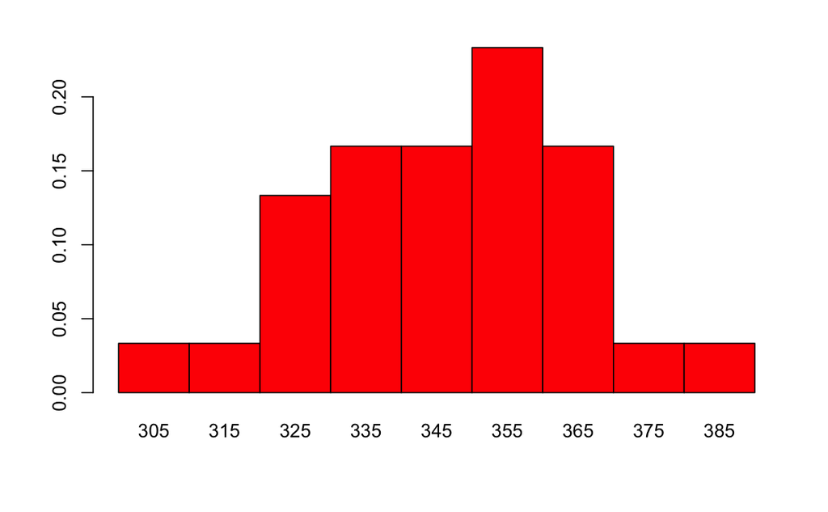

```r
# 相対度数分布表を作成
freqtable <- data.frame(
  freq,                     # 度数分布表
  "相対度数"=rela_freq,     # 階級ごとの相対度数
  "累積相対度数"=cumu_freq  # 階級ごとの累積相対度数
)

# 相対度数の棒グラフを作成
barplot(
  freqtable$相対度数,          # 「freqtableの$相対度数」をグラフにする
  names.arg = freqtable$階級値,# グラフの横軸を階級値にする
  col = "RED",                 # 棒の色は赤
  border = TRUE,               # 棒の境界線を表示
  space = 0                    # 棒と棒の間のスペースは0
)
```

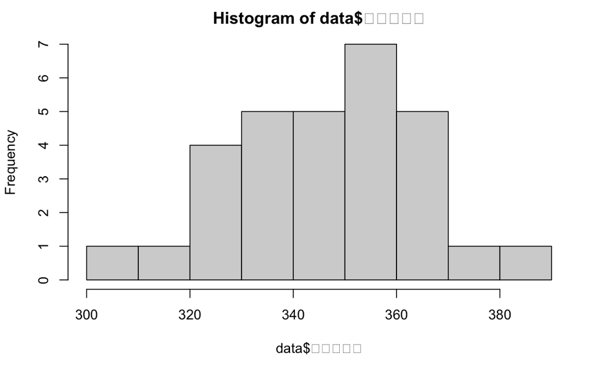

```r
# 「frequency-function.R」を読み込む
source("data/frequency-function.R", encoding="UTF-8")
# access.csvをデータフレームとしてdataに代入
df <- read.csv("data/access.csv", encoding="UTF-8")
# frequency()関数を実行して相対度数分布表を出力する
frq = frequency(df)
```

## 3.5 平均の足を引っ張るデータを除外する（トリム平均）

### 3.5.1 平均は真ん中くらいの値ではなかった

#### 3.5.1.1 mean()関数のオプションを使って「トリム平均」を求める

```r
# 店舗別売上.txtをデータフレームdataに代入
data <- read.table(
  "data/店舗別売上.txt",    # 対象のファイル
  header=TRUE,         # 1行目は見出し
  fileEncoding="UTF-8" # 文字コードの変換方式
)
# 各店舗の売上高の平均を求める
average = mean(data$"売上高_千円")
# 出力
average
```

```
[1] 2889.35
```

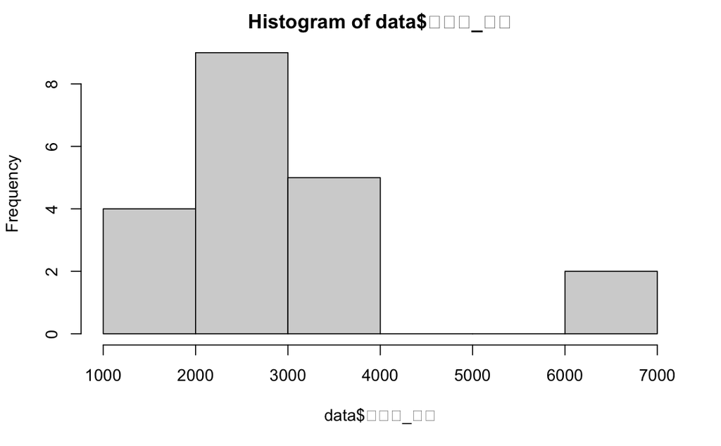

```r
# 各店舗の売上高をヒストグラムにする
hist(data$"売上高_千円")
```

```r
# 売上高が0のダミーデータを2件追加
data = rbind(
  data,
  data.frame(店舗名="dummy", 売上高_千円=0),
  data.frame(店舗名="dummy", 売上高_千円=0)
  )

# 上側と下側からそれぞれの2件の外れ値を除いた
# トリム平均を求める
trim_mean = mean(
  data$"売上高_千円", # 集計の対象
  trim = 0.1          # 上側と下側の10％を除外
)
# 出力
trim_mean
```

```
[1] 2483.889
```

## 3.6 しっくりこないならど真ん中の値を見付けよう（中央値）

### 3.6.1 平均とは違う、データの「ど真ん中」の値

#### 3.6.1.1 散らばったデータのど真ん中を指す中央値

#### 3.6.1.2 summary()関数で最大、最小、平均、中央値をまとめて調べる

```r
# 店舗別売上.txtをデータフレームに読み込む
data <- read.table(
  "data/店舗別売上.txt",    # ファイル名
  header=T,            # 1行目は列名であることを指定
  fileEncoding="UTF-8" # 文字コードの変換方式
)
# 中央値を求める
m <- median(data$売上高_千円)
# 出力
cat("中央値", m)
```

```
中央値 2464.5
```

```r
# データのサマリを出力する関数
showSummary <- function(data) {
  smm = summary(data)
  cat("最小値", smm["Min."] ,"\n")
  cat("第一数", smm["1st Qu."],"\n")
  cat("中央値", smm["Median"],"\n")
  cat("平均値", smm["Mean"],"\n")
  cat("第三数", smm["3rd Qu."],"\n")
  cat("最大値", smm["Max."],"\n")
}

# 店舗別売上.txtをデータフレームに読み込む
data <- read.table(
  "data/店舗別売上.txt",
  header=T,
  fileEncoding="UTF-8"
)

# データフレームの列を引数にしてshowSummary()関数を実行
showSummary(data$売上高_千円)
```

```
最小値 1654
第一数 2129
中央値 2464.5
平均値 2889.35
第三数 3203.25
最大値 6612
```

# 4 データのバラツキ具合を知る（偏差、分散、標準偏差）

## 4.1 データのバラツキ具合を数字で表す（偏差、分散）

### Memo 分散と不偏分散

### 4.1.1 個々のデータの平均との差を調べて全体の散らばり具合を知る

#### 4.1.1.1 平均からどのくらい離れているのかを表すのが「偏差」

#### 4.1.1.2 偏差を求める

### 4.1.2 偏差を2乗した「偏差平均」を平均して「分散」を求める

#### 4.1.2.1 偏差平方の平均が「分散」

## 4.2 そのデータは「優秀」なのかそれとも「普通」？（標準偏差）

### Memo 平均や分散、標準偏差の記号について

### 4.2.1 新規オープン店の売上数は突出しているのか

#### 4.2.1.1 分散をデータの単位に戻して比較できるようにする

### 4.2.2 データの特殊性を「標準化」した数値で表す

#### 4.2.2.1 商品Aと商品Bの販売数をすべて標準化する

### Memo 平方根について

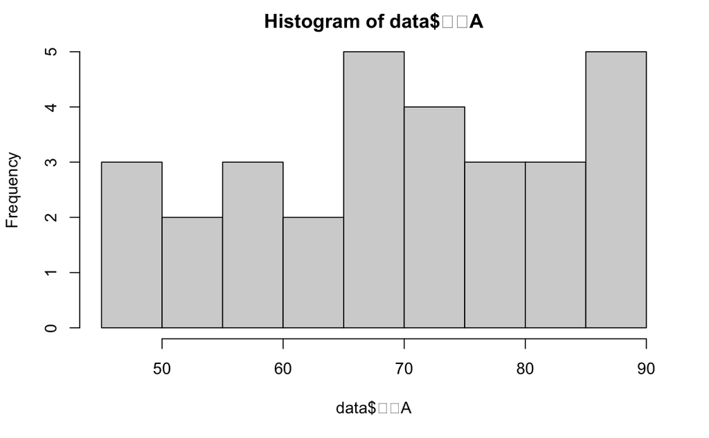

```r
# 販売数.txtをデータフレームに格納
data <- read.table(
  "data/販売数.txt",
  header=T,                 # 1行目は列名
  fileEncoding="UTF-8"      # 文字コードの変換方式
)
# 商品Aのヒストグラムを作成
hist(data$商品A)
```

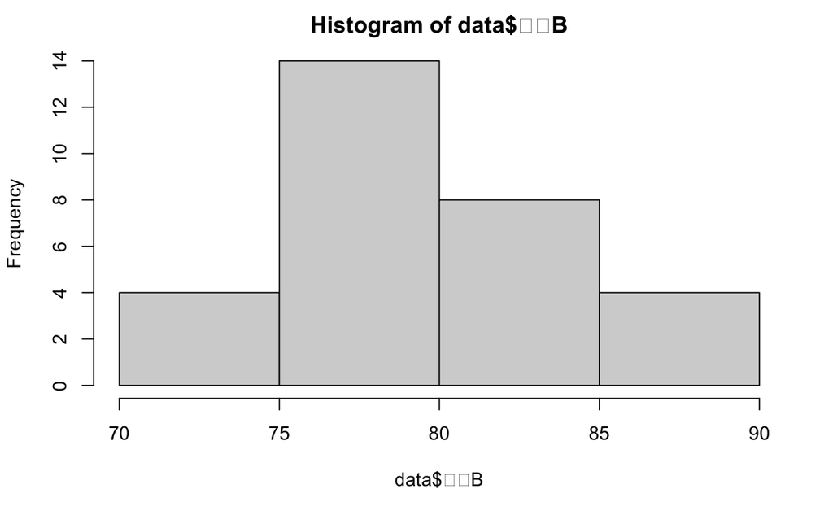

```r
# 商品Bのヒストグラムを作成
hist(data$商品B)
```

```r
# 商品Aの平均を求める
mean_A = mean(data$商品A)
# 商品Aの販売数をベクトルに代入
num_A <- data$商品A
# 商品Aの偏差を求める
dev_A <- num_A - mean_A
# 出力
cat("商品Aの偏差：\n",dev_A, "\n")
```

```
商品Aの偏差：
 -19 -7 -7 20 -22 2 -22 -1 17 17 14 5 8 11 -13 17 5 -13 -22 -13 -1 11 -16 20 8 -4 -4 2 8 -1
```

```r
# 商品Bの平均を求める
mean_B = mean(data$商品B)
# 商品Bの販売台数をベクトルに代入
num_B <- data$商品B
# 商品Bの偏差を求める
dev_B <- num_B - mean_B
# 出力
cat("商品Bの偏差：\n",dev_B, "\n")
```

```
商品Bの偏差：
 2 -2 0 -4 2 6 0 6 0 -3 2 0 -6 6 -10 0 4 2 -4 2 -6 -2 -2 -6 2 0 0 9 -2 4
```

```r
# 商品Aの分散を求める
dspr_A <- sum(dev_A^2) / length(data$商品A)
# 出力
cat("商品Aの分散：", dspr_A, "\n")
```

```
商品Aの分散： 168.8
```

```r
# 商品Bの分散を求める
dspr_B <- sum(dev_B^2) / length(data$商品B)
# 出力
cat("商品Bの分散：", dspr_B, "\n")
```

```
商品Bの分散： 17
```

## 4.3 来客数が平均より多いのは「繁盛」しているといえるか

### 4.3.1 標準偏差を「尺度」にする

#### 4.3.1.1 来客数の標準偏差と標準化係数を求める

### 4.3.2 データの偏差が標準偏差の±1個ぶんの範囲内であれば平凡なデータだと判断できる

#### 4.3.2.1 標準化係数でデータの特殊性を知る

#### 4.3.2.2 標準化した値の平均は0で標準偏差は1

```r
# 分散を求める関数
getDisper <- function(x) {
  # 偏差を求める
  dev <- x - mean(x)
  # 偏差平方和をデータ数で割った分散を返す
  return(sum(dev^2) / length(x))
}

# 販売数.txtをデータフレームに読み込む
data <- read.table(
  "data/販売数.txt",
  header=TRUE,         # 1行目は列名
  fileEncoding="UTF-8" # 文字コードの変換方式
)

# 商品Aのデータをベクトルに代入
num_A  <- data$商品A
# 商品Aの分散を求める
dspr_A <- getDisper(num_A)
# 平方根をとって標準偏差を求める
sd_A   <- sqrt(dspr_A)
# 出力
cat("商品Aの標準偏差：", sd_A, "\n")
```

```
商品Aの標準偏差： 12.99231
```

```r
# 商品Bのデータをベクトルに代入
num_B  <- data$商品B
# 商品Bの分散を求める
dspr_B <- getDisper(num_B)
# 平方根をとって標準偏差を求める
sd_B   <- sqrt(dspr_B)
# 出力
cat("商品Bの標準偏差：", sd_B, "\n")
```

```
商品Bの標準偏差： 4.123106
```

```r
# 標準偏差を求める関数
getSD <- function(x) {
  # 分散の平方根をとった値(標準偏差)を返す
  return(
    sqrt(sum((x - mean(x))^2) / length(x)))
}

# 販売数.txtをデータフレームに読み込む
data <- read.table(
  "data/販売数.txt",
  header=T,            # 1行目は列名
  fileEncoding="UTF-8" # 文字コードの変換方式
)

# 商品Aのデータをベクトルに代入
num_A  <- data$商品A
# 商品Aの標準偏差を求める
sd_A <- getSD(num_A)
# 出力
cat("商品Aの標準偏差：", sd_A, "\n")
```

```
商品Aの標準偏差： 12.99231
```

```r
# 商品Bのデータをベクトルに代入
num_B  <- data$商品B
# 商品Bの標準偏差を求める
sd_B   <- getSD(num_B)
# 出力
cat("商品Bの標準偏差：", sd_B, "\n")
```

```
商品Bの標準偏差： 4.123106
```

```r
# 標準偏差を求める関数
getSD <- function(x) {
  # 分散の平方根をとった値(標準偏差)を返す
  return(
    sqrt(sum((x - mean(x))^2) / length(x)))
}

# 販売数.txtをデータフレームに読み込む
data <- read.table(
  "data/販売数.txt",
  header=T,            # 1行目は列名
  fileEncoding="UTF-8" # 文字コードの変換方式
)

# 商品Aのデータをベクトルに代入
num_A  <- data$商品A
# 商品Aの平均を求める
mean_A  <- mean(num_A)
# 商品Aの標準偏差を求める
sd_A <- getSD(num_A)
# 商品Aの売上数を標準化
standardize_A <- (num_A - mean_A)/sd_A
# 出力
standardize_A
```

```
 [1] -1.46240405 -0.53878044 -0.53878044  1.53937268 -1.69330995  0.15393727 -1.69330995
 [8] -0.07696863  1.30846678  1.30846678  1.07756088  0.38484317  0.61574907  0.84665497
[15] -1.00059224  1.30846678  0.38484317 -1.00059224 -1.69330995 -1.00059224 -0.07696863
[22]  0.84665497 -1.23149814  1.53937268  0.61574907 -0.30787454 -0.30787454  0.15393727
[29]  0.61574907 -0.07696863
```

```r
# 商品Bのデータをベクトルに代入
num_B  <- data$商品B
# 商品Bの平均を求める
mean_B  <- mean(num_B)
# 商品Bの標準偏差を求める
sd_B   <- getSD(num_B)
# 商品Bの売上数を標準化
standardize_B <- (num_B - mean_B)/sd_B
# 出力
standardize_B
```

```
 [1]  0.4850713 -0.4850713  0.0000000 -0.9701425  0.4850713  1.4552138  0.0000000  1.4552138
 [9]  0.0000000 -0.7276069  0.4850713  0.0000000 -1.4552138  1.4552138 -2.4253563  0.0000000
[17]  0.9701425  0.4850713 -0.9701425  0.4850713 -1.4552138 -0.4850713 -0.4850713 -1.4552138
[25]  0.4850713  0.0000000  0.0000000  2.1828206 -0.4850713  0.9701425
```

```r
# 売上数(95)を商品Aの標準偏差で標準化して出力
(95 - mean_A)/sd_A
```

```
[1] 1.924216
```

```r
# 売上数(95)を商品Bの標準偏差で標準化して出力
(95 - mean_B)/sd_B
```

```
[1] 3.638034
```

```r
# 商品Aの標準化係数の平均
mean(standardize_A)
```

```
[1] 1.017704e-17
```

```r
# 商品Bの標準化係数の平均
mean(standardize_B)
```

```
[1] -1.480297e-17
```

### Hint データに手を加えると平均、分散はどうなる？

## 4.4 来店者の数が上位5％に入る日を調べる

### 4.4.1 正規分布のグラフの形は平均と標準偏差で決まる

#### 4.4.1.1 標準正規分布のグラフ

#### 4.4.1.2 確率密度関数

### 4.4.2 標準正規分布のグラフ中の区切られた領域がデータの出現率を表す

#### 4.4.2.1 標準正規分布の数表をRで作成してみる

#### 4.4.2.2 Rで標準正規分布の数表を作成する

#### 4.4.2.3 標準正規分布の数表の見方

### 4.4.3 上位5％に入る来店者数を見付けよう

#### 4.4.3.1 標準正規分布の数表を使って上位5％の区間面積に対するxの値を求めよう

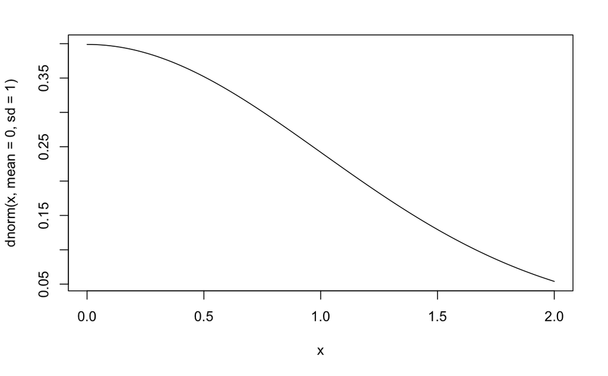

```r
# 0～2を0.01刻みにしたシーケンス(数列)を生成
n <- seq(0, 2, by = 0.01) # ---------------------①
# 標準正規分布の確率密度関数で確率密度を求める
dn <- dnorm(n, mean=0, sd=1) # ------------------②

# 区間面積用の空の数値ベクトルを作る
s_area <- as.numeric(NULL) # --------------------③
# 累積面積用の数値ベクトルを作る
t_area <- as.numeric(NULL) # --------------------④

# 区間面積と累計面積を計算
# カウンター変数
i <- 0 # ----------------------------------------⑤
# nの要素の数だけ繰り返す
for (value in n){ # -----------------------------⑥
  # valueが0のときの初期化処理
  if(value == 0){ # -----------------------------⑦
    s_area <- 0  # 区間面積を0とする
    t_area <- 0  # 累計面積を0とする
    i <- i + 1   # カウンターの値を1増やす
  } else { # ------------------------------------⑧
    # valueが0以外(2回目以降)の処理
    # 区間面積のベクトルに現在の区間面積を追加
    s_area <- c(
      # s_areaの末尾に連結する
      s_area,
      # 現在の区間面積を台形の面積で近似する
      # 0.01区切りなので台形の高さは0.01
      (dn[i] + dn[i+1]) * 0.01 / 2
      )
    # 累計面積のベクトルに現在の累計面積を追加
    t_area <- c(
      # t_areaの末尾に連結する
      t_area,
      # 累計面積に現在の区間面積を加算する
      t_area[i] + s_area[i+1]
    )
    # カウンター変数に1を加算
    i <- i + 1
    }
}

# 標準正規分布の数表としてデータフレームを作成
dframe <- data.frame( # -------------------------⑨
  x_value = n,           # x_valueカラムは0～2までの連続値
  section_area = s_area, # section_areaカラムは区間面積
  total_area   = t_area  # total_areaカラムは累計面積
)

# 数表をテキストファイルに保存
write.table(
  dframe,                      # 書き出すデータフレーム
  file="data/std-distribution.txt", # ファイル名
  sep="\t",                    # 区切り文字
  row.names = FALSE)           # 設定されている行番号は書き込みしない

# x=1からx=2までの区間の確率密度をグラフにする
curve(dnorm(x,mean=0, sd=1), from=0, to =2)
```

```r
# 上位5%に入る来店者数
qnorm(0.95, mean=54, sd=10)
```

```
[1] 70.44854
```

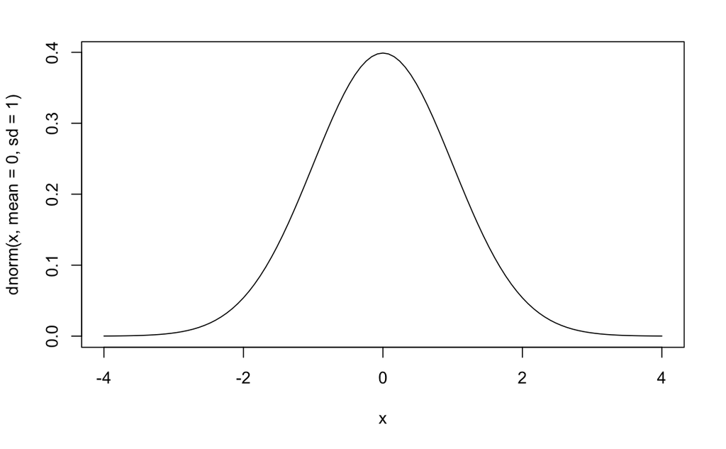

```r
# 標準正規分布のグラフを-4から4までの区間で描く
curve(dnorm(x,mean=0, sd=1), from=-4, to =4)
```

# 5 正規分布するデータを解析する

## 5.1 売上の平均が38万円のとき45万円以上売上げる確率は？

### Hint 数学定数の「ネイピア数」

### 5.1.1 標準正規分布ではないふつうの分布は「一般正規分布」

#### 5.1.1.1 正規分布をσ＝1、μ＝0に換算して標準正規分布にする

#### 5.1.1.2 正規分布のxを求める確率密度関数f(x)

#### 5.1.1.3 Onepoint ××万円以上○○万円以下の売上が発生する確率は？

### 5.1.2 売上が40万円以上になる確率を求めてみよう

#### 5.1.2.1 30万～60万円を5万円刻みにして、それぞれの累積確率を求める

```r
# 売上状況.txtをデータフレームに格納
data <- read.table(
  "data/売上状況.txt",      # ファイル名
  header=TRUE,         # 1行目は列名であることを指定
  fileEncoding="UTF-8" # 文字コードの変換方式
)

# 標準偏差を返す関数
getSd <- function(x) {
  return(sqrt(                         # 分散の平方根
    sum((x - mean(x))^2) / length(x))) # 分散の計算式
  }

# 売上額のデータをベクトルに格納
num <- data$売上額
# 売上額の標準偏差を求める
sales_sd <- getSd(num)
# 30～60までの5刻みのシーケンスを生成
seq <- seq(30, 60, by=5)

# 累積確率を求める
cmp <- pnorm(
  seq,                      # 累積確率を求めるデータ
  mean = mean(data$売上額), # 売上額の平均
  sd = sales_sd,            # 売上額の標準偏差
  lower.tail = TRUE         # 下側の累積確率を求める
)

# 30～60万円までの5万円刻みの売上額と累積確率をデータフレームに格納
prob <- data.frame(
  "売上額"=seq,
  "累積確率"=cmp
)

# 売上が40万円以上になる確率を求める
1 - prob[3,2]
```

```
[1] 0.4416215
```

## 5.2 偏差値の仕組み

### 5.2.1 標準化した値を10倍にして50を足すのは何のためか

#### 5.2.1.1 偏差値を求めてみる

### 5.2.2 標準偏差を用いた合格判定の仕組み

#### 5.2.2.1 平均と標準偏差、あとはデータの数で合否を推測する

```r
# テスト結果.txtをデータフレームに格納
data <- read.table(
  "data/テスト結果.txt",    # ファイル名
  header=T,            # 1行目は列名
  fileEncoding="UTF-8" # 文字コードの変換方式
)

# 標準偏差を返す関数
getSd <- function(x) {
  return(sqrt(                         # 分散の平方根
    sum((x - mean(x))^2) / length(x))) # 分散の計算式
}

# 得点をベクトルに代入
score <- data$得点
# 得点の標準偏差を求める
score_sd <- getSd(score)
# 得点の平均
men <- mean(score)
# 全員の偏差値を求める
dev <- (data$得点 - men)/score_sd*10 + 50

# 偏差値をデータフレームに追加
data <- cbind(
  data,                       # もとのデータフレーム
  data.frame("偏差値" = dev)  # 偏差値のデータフレームを作成
  )
```

```r
pnorm(2, mean=0,sd=1) - 0.5
```

```
[1] 0.4772499
```

```r
pnorm(80, mean=60,sd=10)
```

```
[1] 0.9772499
```

```r
1 - 0.9772499
```

```
[1] 0.0227501
```

```r
pnorm(80, mean=56, sd=8)
```

```
[1] 0.9986501
```

## 5.3 バラバラに分布するデータを正規分布に近似する（大数の法則）

### 5.3.1 1000人ぶんのサンプルで10万人ぶんの相対度数分布グラフが描かれる

#### 5.3.1.1 10万人の中から1人ずつ選んで1000回計測したらどうなる？（復元抽出）

#### 5.3.1.2 非復元抽出と復元抽出

### Hint 相対度数分布グラフはなぜ曲線の山の形をしている？

## 5.4 正規分布の再生性

### 5.4.1 正規分布は2つを重ねても分布の形が保存される

#### 5.4.1.1 正規分布の再生性

```r
qnorm(0.5+0.45, mean=0, sd=1)
```

```
[1] 1.644854
```

```r
110 + 10*1.64
```

```
[1] 126.4
```

### Memo 「大数の法則」でサンプルの相対度数分布が母集団のデータとぴったり一致！

### Memo 中心極限定理

## 5.5 ピンポイントでズバリ当てる（点推定）

### 5.5.1 母集団と標本

#### 5.5.1.1 全数調査と標本調査

#### 5.5.1.2 無作為抽出（ランダムサンプリング）

### 5.5.2 ピンポイントで推定する

#### 5.5.2.1 最尤法による推定

#### 5.5.2.2 不偏推定量による推定

#### 5.5.2.3 点推定の結果を見る

```r
# 英語のテスト結果
test <- c(
  75, 68, 96, 76, 84, 74, 64,   94, 77, 82,
  86, 56,   82, 69, 59, 81, 61, 85, 64, 63,
  68,   79, 61, 57, 63, 89, 74, 63, 71, 69,
  95,   84, 76
)

# 分散を返す関数
getDisper <- function(x) {
  # すべてのデータについて偏差を求める
  dev <- x - mean(x)
  # 分散を返す
  return(sum(dev^2) / length(x))
}

# 先頭から5人の平均点を求める
cat("標本平均:", mean(test[1:5]))
```

```
標本平均: 79.8
```

```r
# 先頭から5人の分散を求める
cat("標本分散:", getDisper(test[1:5]))
```

```
標本分散: 91.36
```

```r
# 先頭から5人の不偏分散を求める
cat("不偏分散:", var(test[1:5]))
```

```
不偏分散: 114.2
```

```r
# 10人の得点
test <- c(3, 3, 4, 4, 5, 5, 5, 6, 7, 8)
# 標本平均
mean(test)
```

```
[1] 5
```

```r
# 不偏分散
var(test)
```

```
[1] 2.666667
```

## 5.6 サイコロを振ると1の目が出る確率は？

### 5.6.1 確率変数とその定義

#### 5.6.1.1 偶数の目が出る確率は

### Hint 離散と連続の違いは？

#### 5.6.1.2 確率の定義

#### 5.6.1.3 離散型一様分布の確率質量関数

#### 5.6.1.4 サイコロを振ると本当に6分の1の確率で各目が出るのか

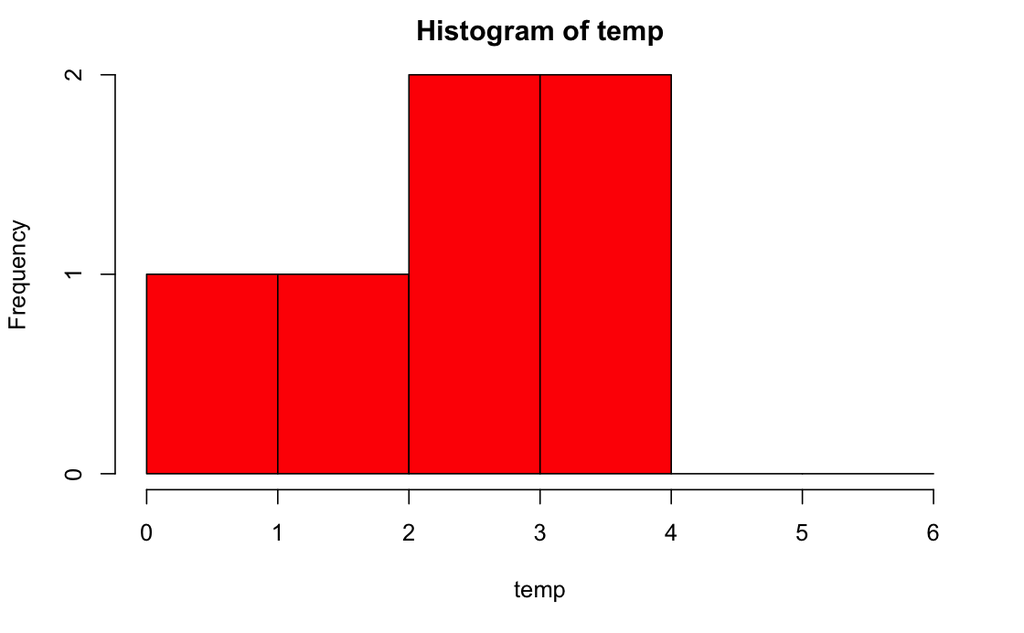

```r
# 1～6までの範囲の値を6回、ランダムに生成する
# runif()の出力は小数を含むのでfloor()で切り捨てる
temp<-floor(runif(6, # 試行回数
                  1, # 出力する乱数の最小値
                  7) # 出力する乱数の最大値の次の値
)

# ヒストグラムを作成
hist(temp,
     breaks = seq(0, # 下限
                  6, # 上限
                  1  # 階級の幅
     ),
     freq = TRUE, # 度数を表示
     col="red"    # 棒の色は赤
)
```

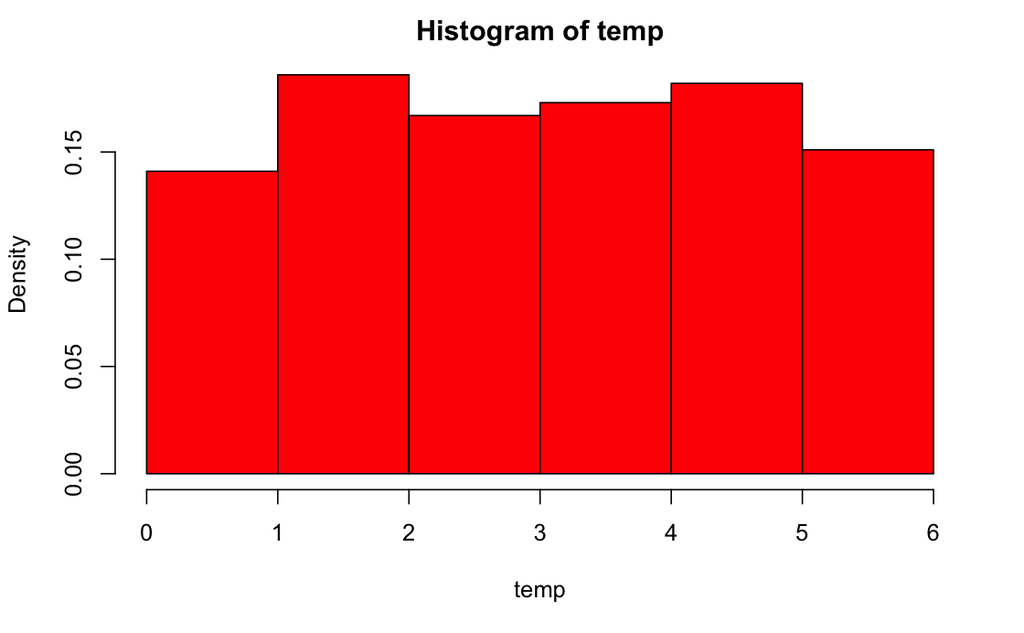

```r
# 1～6までの範囲の値を1000回、ランダムに生成する
# runif()の出力は小数を含むのでfloor()で切り捨てる
temp<-floor(runif(1000, # 試行回数を1000にする
                  1, # 出力する乱数の最小値
                  7) # 出力する乱数の最大値の次の値
)

# ヒストグラムを作成
hist(temp,
     breaks = seq(0, # 下限
                  6, # 上限
                  1  # 階級の幅
     ),
     freq = FALSE, # 相対度数を表示
     col="red"     # 棒の色は赤
)
```

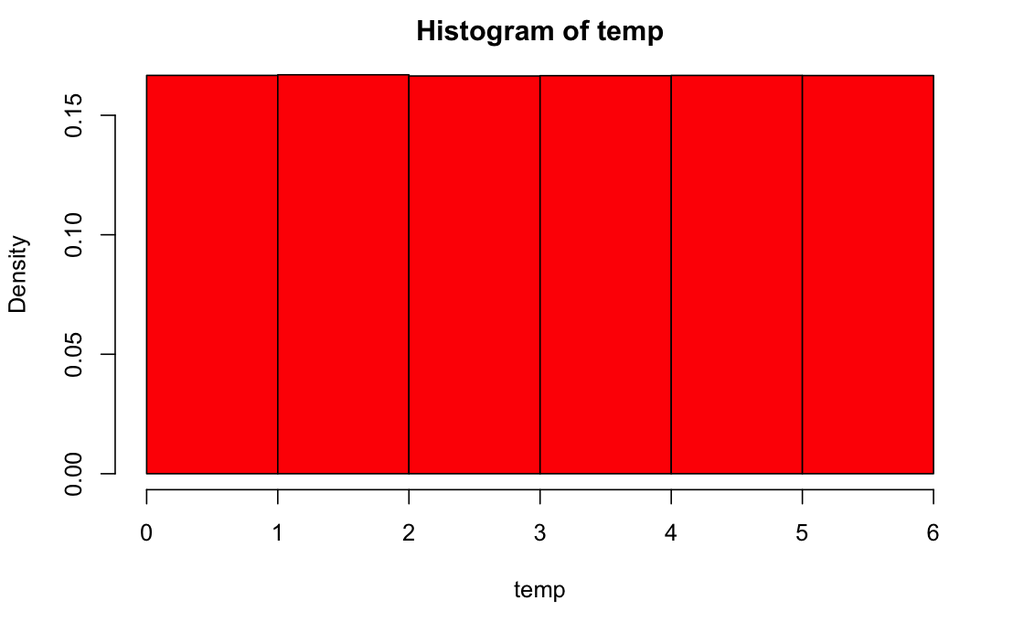

```r
# 1～6までの範囲の値を500万回、ランダムに生成する
# runif()の出力は小数を含むのでfloor()で切り捨てる
temp<-floor(runif(5000000, # 試行回数を500万にする
                  1, # 出力する乱数の最小値
                  7) # 出力する乱数の最大値の次の値
)

# ヒストグラムを作成
hist(temp,
     breaks = seq(0, 6, 1),
     freq = FALSE, # 相対度数を表示
     col="red")    # 棒の色は赤
```

## 5.7 「標本平均の平均」をとると母平均にかなり近くなる

### 5.7.1 母集団から5個のサンプルをランダムに抽出する

#### 5.7.1.1 sample()関数によるランダムサンプリング

#### 5.7.1.2 母集団の平均と標本の平均

#### 5.7.1.3 標本分布で推定するときのポイント2つ

### 5.7.2 標本分布が母集団の本当の値を中心として分布しているか

#### 5.7.2.1 標本平均の数が大きくなると標本分布が正規分布に近くなっていく

#### 5.7.2.2 標本平均の分散と標準誤差を確認する

### 5.7.3 サンプルサイズを大きくすると標準誤差は本当に小さくなるのか

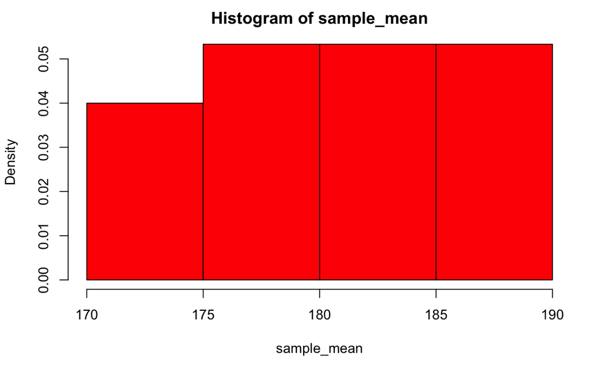

```r
# 計測結果.txtをデータフレームに読み込む
data <- read.table(
  "data/計測結果.txt",
  header=T,            # 1行目は列名であることを指定
  fileEncoding="UTF-8" # 文字コードの変換方式
)

# 5個のサンプルの平均を保持するベクトルを用意
sample_mean <- as.numeric(NULL)

# 処理を15回繰り返す
for (i in 1:15){
  # サンプリングを行う
  sample <- sample(data$容量,      # 抽出元のデータ
                   5,              # サンプルサイズ
                   replace = FALSE # 復元抽出は行わない
                   )
  # 標本平均を求めてsample_meanに追加
  sample_mean <- c(sample_mean, mean(sample))
}

# 標本平均の平均を求める
s_mean <- mean(sample_mean)
# データ全体の平均を求める
p_mean <- mean(data$容量)

# すべての標本平均をヒストグラムにする
hist(sample_mean,  # 標本平均
     freq = FALSE, # 相対度数を表示
     col="red"     # 棒の色は赤
     )
```

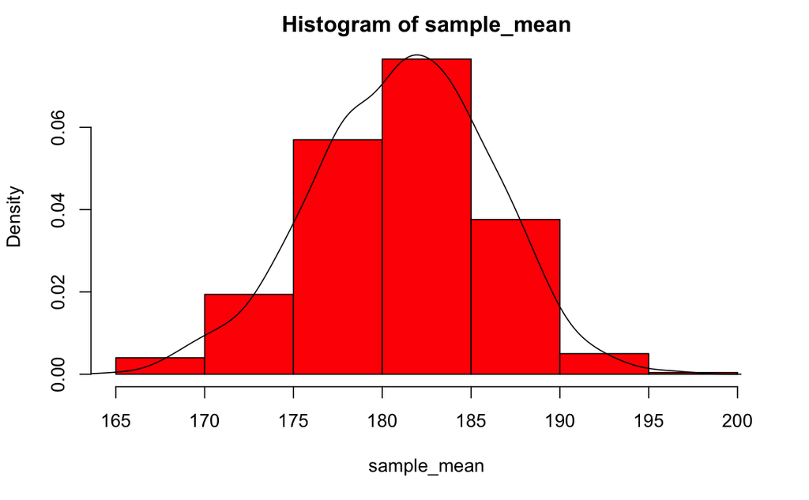

```r
# 計測結果.txtをデータフレームに読み込む
data <- read.table(
  "data/計測結果.txt",
  header=T,            # 1行目は列名であることを指定
  fileEncoding="UTF-8" # 文字コードの変換方式
)

# 標本平均を保持するベクトル
sample_mean <- as.numeric(NULL)
# 繰り返す回数をベクトルに代入
rp <- c(1:1000)
# サンプルサイズをベクトルに代入
size <- 5

# 処理を1000回繰り返す
for (i in rp){
  # サンプリングを行う
  sample <- sample(data$容量,      # 抽出元のデータ
                   5,              # サンプルサイズ
                   replace = FALSE # 復元抽出は行わない
  )
  # 標本平均を求めてsample_meanに追加
  sample_mean <- c(sample_mean, mean(sample))
}

# 標本平均の平均を求める
s_mean <- mean(sample_mean)
# データ全体の平均を求める
p_mean <- mean(data$容量)

# すべての標本平均をヒストグラムにする
hist(sample_mean,  # 標本平均
     freq = FALSE, # 相対度数を表示
     col="red"     # 棒の色は赤
)

# 確率密度の近似値をラインで描画
lines(density(sample_mean))
```

```r
# 分散を求める関数
getDisper <- function(x) {
  dev <- x - mean(x)             # 偏差を求める
  return(sum(dev^2) / length(x)) # 分散を返す
}

# 標準偏差を返す関数
getSD <- function(x) {
  # 分散の平方根を返す
  return(
    sqrt(sum((x - mean(x))^2) / length(x))
    )
}

# 標本平均の分散を求める
sample_mean_disper <- getDisper(sample_mean)
# 母集団から標本平均の分散を推定
estimate_disper <- getDisper(data$容量)/size
# 標本平均の分散から標準誤差を求める
error_disp <- sqrt(sample_mean_disper)
# 母集団の標準偏差をサンプルサイズの平方根で割って
# 標準誤差を求める
error_sd <-getSD(data$容量)/sqrt(size)
```

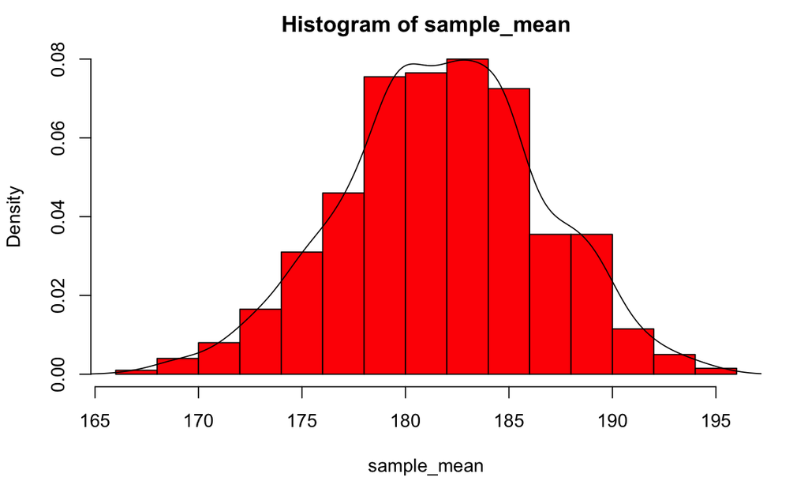

```r
# 計測結果.txtをデータフレームに読み込む
data <- read.table(
  "data/計測結果.txt",
  header=T,            # 1行目は列名であることを指定
  fileEncoding="UTF-8" # 文字コードの変換方式
)

# 標本平均を保持するベクトル
sample_mean <- as.numeric(NULL)
# 繰り返す回数をベクトルに代入
rp <- c(1:1000)
# サンプルサイズをベクトルに代入
size <- 20

# 処理を1000回繰り返す
for (i in rp){
  # サンプリングを行う
  sample <- sample(data$容量,      # 抽出元のデータ
                   5,              # サンプルサイズ
                   replace = FALSE # 復元抽出は行わない
  )
  # 標本平均を求めてsample_meanに追加
  sample_mean <- c(sample_mean, mean(sample))
}



# すべての標本平均をヒストグラムにする
hist(sample_mean,  # 標本平均
     freq = FALSE, # 相対度数を表示
     col="red"     # 棒の色は赤
)

# 確率密度の近似値をラインで描画
lines(density(sample_mean))
```

```r
# 分散を求める関数
getDisper <- function(x) {
  dev <- x - mean(x)             # 偏差を求める
  return(sum(dev^2) / length(x)) # 分散を返す
}

# 標準偏差を返す関数
getSD <- function(x) {
  # 分散の平方根を返す
  return(
    sqrt(sum((x - mean(x))^2) / length(x))
  )
}

# 標本平均の分散を求める
sample_mean_disper <- getDisper(sample_mean)
# 母集団から標本平均の分散を推定
estimate_disper <- getDisper(data$容量)/size
# 標本平均の分散から標準誤差を求める
error_disp <- sqrt(sample_mean_disper)
# 母集団の標準偏差をサンプルサイズの平方根で割って
# 標準誤差を求める
error_sd <-getSD(data$容量)/sqrt(size)
```

## 5.8 データ全体の散らばりと標本平均の散らばり

### 5.8.1 標本平均の分散を調べる

#### 5.8.1.1 標本平均の分散と母分散の関係を調べる

```r
# 計測結果.txtをデータフレームに読み込む
data <- read.table(
  "data/計測結果.txt",
  header=TRUE,         # 1行目は列名
  fileEncoding="UTF-8" # 文字コードの変換方式
)

# 標本平均を保持するベクトルを用意
sample_mean <- as.numeric(NULL)

# 処理を15回繰り返す
for(i in 1:15){
  # サンプリングを行う
  sample   <- sample(
    data$容量,      # 抽出元のデータ
    5,              # サンプルサイズ
    replace = FALSE # 復元抽出は行わない
  )
  # 標本平均を求めてsample_meanに追加
  sample_mean <- c(sample_mean, mean(sample))
}

# 分散を求める関数
getDisper <- function(x) {
  dev <- x - mean(x)             # 偏差を求める
  return(sum(dev^2) / length(x)) # 分散を返す
}

# 標本平均の平均を求める
s_mean <- mean(sample_mean)
# 標本平均の分散を求める
s_var  <- getDisper(sample_mean)
# 母集団の平均を求める
p_mean <- mean(data$容量)
# 母集団の分散を求める
p_var  <- getDisper(data$容量)
```

## 5.9 標本分散の平均

### 5.9.1 標本分散の代わりに不偏分散を推定値として使う

#### 5.9.1.1 標本分散と不偏分散のそれぞれの平均を母分散と比較する

#### 5.9.1.2 母集団と標本の関係のまとめ

```r
# 計測結果.txtをデータフレームに読み込む
data <- read.table(
  "data/計測結果.txt",
  header=TRUE,         # 1行目は列名
  fileEncoding="UTF-8" # 文字コードの変換方式
)

# 分散を求める関数
getDisper <- function(x) {
  dev <- x - mean(x)             # 偏差を求める
  return(sum(dev^2) / length(x)) # 分散を返す
}

# 標本平均を保持するベクトル
sample_mean <- as.numeric(NULL)
# 標本分散を格納するベクトル
sample_disper <- as.numeric(NULL)
# 標本の不偏分散を格納するベクトル
sample_undisper <- as.numeric(NULL)

# 処理を15回繰り返す
for(i in 1:15){
  # サンプリングを行う
  sample <- sample(
    data$容量,      # 抽出元のデータ
    10,             # サンプルサイズ
    replace = FALSE # 復元抽出は行わない
  )
  # サンプルの平均をベクトルに追加
  sample_mean  <- c(sample_mean, mean(sample))
  # 標本分散をベクトルに追加
  sample_disper  <- c(sample_disper, getDisper(sample))
  # 標本の不偏分散をベクトルに追加
  sample_undisper <- c(sample_undisper, var(sample))
}

# 標本平均の平均
ps_mean_mean <- mean(sample_mean)
# 標本分散の平均
s_disper_mean <- mean(sample_disper)
# 標本の不偏分散の平均
s_undisper_mean <- mean(sample_undisper)
# 母集団の平均
p_mean <- mean(data$容量)
# 母集団の分散
p_disper <- getDisper(data$容量)
```

# 6 手持ちのデータで全体を知る（標本と母集団）

## 6.1 大標本を使って全体の平均を予測する（z値を用いた区間推定）

### 6.1.1 降水確率に見る区間推定の考え方

#### 6.1.1.1 区間推定の考え方

#### 6.1.1.2 信頼区間と信頼度

### Memo 信頼度95％の区間推定

#### 6.1.2.1 大標本（サンプルサイズ30以上）の信頼区間

#### 6.1.2.2 母平均の信頼区間の関係式を導く

#### 6.1.2.3 サンプルサイズ50で母平均を区間推定する

```r
# 計測結果.txtをデータフレームに読み込む
data <- read.table(
  "data/計測結果.txt",
  header=TRUE,         # 1行目は列名
  fileEncoding="UTF-8" # 文字コードの変換方式
)

# 分散を求める関数
getDisper <- function(x) {
  dev <- x - mean(x)             # 偏差を求める
  return(sum(dev^2) / length(x)) # 分散を返す
}

# 標本平均を保持するベクトル
sample_mean <- as.numeric(NULL)
# 標本分散を格納するベクトル
sample_disper <- as.numeric(NULL)
# 標本の不偏分散を格納するベクトル
sample_undisper <- as.numeric(NULL)

# 処理を15回繰り返す
for(i in 1:15){
  # サンプリングを行う
  sample <- sample(
    data$容量,      # 抽出元のデータ
    10,             # サンプルサイズ
    replace = FALSE # 復元抽出は行わない
  )
  # サンプルの平均をベクトルに追加
  sample_mean  <- c(sample_mean, mean(sample))
  # 標本分散をベクトルに追加
  sample_disper  <- c(sample_disper, getDisper(sample))
  # 標本の不偏分散をベクトルに追加
  sample_undisper <- c(sample_undisper, var(sample))
}

# 標本平均の平均
ps_mean_mean <- mean(sample_mean)
# 標本分散の平均
s_disper_mean <- mean(sample_disper)
# 標本の不偏分散の平均
s_undisper_mean <- mean(sample_undisper)
# 母集団の平均
p_mean <- mean(data$容量)
# 母集団の分散
p_disper <- getDisper(data$容量)
```

```r
# 容量検査.txtをデータフレームに格納
data <- read.table(
  "data/容量検査.txt",
  header=TRUE,         # 1行目は列名
  fileEncoding="UTF-8" # 文字コードの変換方式
)
# 信頼度を99%に設定
prob <- 0.99
# z値を求める
z  <- abs(qnorm((1 - prob) / 2))
# サンプルサイズを求める
n  <- length(data$容量)
# 標本平均を求める
m  <- mean(data$容量)
# 標本標準偏差を求める
sd <- sd(data$容量)
# 下側境界値
border_low <- m - z*(sd/sqrt(n))
# 上側境界値
border_upp <- m + z*(sd/sqrt(n))
```

## 6.2 小標本を使って全体の平均を予測する（t値を用いた区間推定）

### 6.2.1 小標本による平均値の推定

#### 6.2.1.1 小標本の平均と分散を用いて母平均の信頼区間を求める

#### 6.2.1.2 Onepoint 自由度

### 6.2.2 信頼度95％で母平均を区間推定する

#### 6.2.2.1 小標本による区間推定の結果

```r
# 容量検査10.txtをデータフレームに格納
data <- read.table(
  "data/容量検査10.txt",
  header=TRUE,         # 1行目は列名
  fileEncoding="UTF-8" # 文字コードの変換方式
)

# 信頼度を設定
prob <- 0.95
# サンプルサイズを求める
n <- length(data$容量)
# 標本平均を求める
m <- mean(data$容量)
# 標本の不偏分散を求める
vr <- var(data$容量)

# t(α/2, n-1)の絶対値を求める
t <- abs(qt((1 - prob)/2, # α/2を求める
            n - 1)        # サンプルサイズ - 1
         )
# 下限信頼限界
border_low <- m - t*sqrt(vr/n)
# 上限信頼限界
border_upp <- m + t*sqrt(vr/n)
```

## 6.3 母集団のデータの比率を区間推定する

### 6.3.1 二項分布の確率理論を用いて母集団の割合を推定する

#### 6.3.1.1 離散型の代表的かつ重要な確率分布である「二項分布」

#### 6.3.1.2 二項分布の試行回数を無限大にすると正規分布になる

### Memo 順序を考慮する場合の数は「順列」

### 6.3.2 母集団の「比率」を区間推定する

#### 6.3.2.1 母比率を95％の信頼度で区間推定する

#### 6.3.2.2 支持率45％と47％に「差はある」のか

### Hint 自由度が30を超えると標準正規分布とほぼ同じになる

### Memo 階乗

```r
# 信頼度
prob <- 0.95
# z値を求める
z <- abs(qnorm((1 - prob)/2))
# 比率
p <- 0.45
# 母集団のサイズ
n <- 1000
# 下限信頼限界
border_low <- p - z*sqrt(p*(1 - p)/n)
# 上限信頼限界
border_upp <- p + z*sqrt(p*(1 - p)/n)
```

# 7 独立性の検定と2つの平均の比較（χ2検定、t検定）

## 7.1 2つのデータの独立性の検定（カイ二乗検定）

### 7.1.1 データの分布を検証するカイ二乗検定

#### 7.1.1.1 サイコロを投げて1から6までの目が出る確率

#### 7.1.1.2 サイコロ投げの結果をカイ二乗検定で調べる

#### 7.1.1.3 検定に使用する検定統計量を求める式

#### 7.1.1.4 自由度

#### 7.1.1.5 サイコロ投げ12回の試行結果をχ2検定する

#### 7.1.1.6 χ2検定を行う手順

### Memo 対立仮説と帰無仮説

### Memo 有意水準

### 7.1.2 A店とB店のデータ分布は同じかどうかを判断する

#### 7.1.2.1 「差はない」という帰無仮説を立ててχ2検定を実施

#### 7.1.2.2 A店とB店の売上に差はあるのか

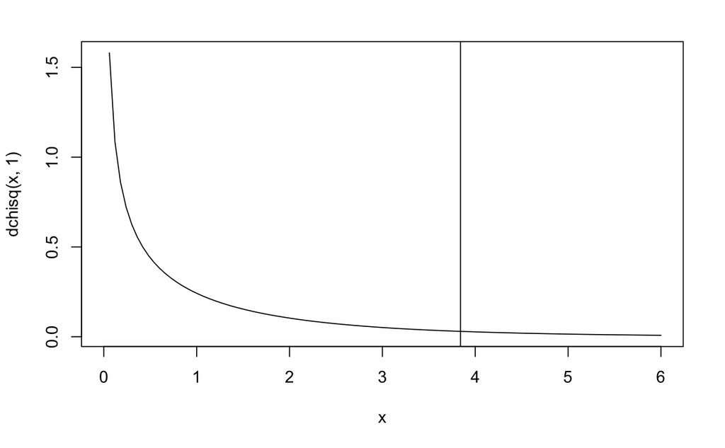

```r
# A店B店.txtをデータフレームに格納
data <- read.table(
  "data/A店B店.txt",
  header=TRUE,         # 1行目は列名
  fileEncoding="UTF-8" # 文字コードの変換方式
)

# A店の注文数の合計
A_sum     <- data[1,3]
# B店の注文数の合計
B_sum     <- data[2,3]
# A店とB店の注文数の合計
AB_sum    <- data[3,3]
# メインメニューの注文数の合計
menu1_sum <- data[3,1]
# セカンドメニューの注文数の合計
menu2_sum <- data[3,2]
# 店舗ごとの注文数をベクトルに格納
menu_sales <- c(data[1,1], # A店のメインメニューの注文数
                data[1,2], # A店のセカンドメニューの注文数
                data[2,1], # B店のメインメニューの注文数
                data[2,2]) # B店のセカンドメニューの注文数

# A店のメインメニューの期待値
exp_A_m1  <- menu1_sum * A_sum / AB_sum
# A店のセカンドメニューの期待値
exp_A_m2  <- menu2_sum * A_sum / AB_sum
# B店のメインメニューの期待値
exp_B_m1  <- menu1_sum * B_sum / AB_sum
# B店のセカンドメニューの期待値
exp_B_m2  <- menu2_sum * B_sum / AB_sum


# すべての期待値をベクトルに格納
exp_freq <- c(exp_A_m1, exp_A_m2, exp_B_m1, exp_B_m2)

# それぞれの売上について「(観測度数-期待値)の2乗÷期待値」を求める
t_element <- (menu_sales - exp_freq) ^2/exp_freq
# 検定統計量を求める
val_t <- sum(t_element)
# 自由度1、有意水準5％のχ2値を求める
val_chi <- qchisq(0.05, # 有意水準
                  1,    # 自由度
                  lower.tail=FALSE) # 上側確率のχ2値

# 自由度1のカイ二乗分布のグラフを描く
curve(dchisq(x, 1), 0, 6)
abline(v=qchisq(0.05, 1,lower.tail=FALSE))
```

```r
# サイコロ.txtをデータフレームに格納
data <- read.table(
  "data/サイコロ.txt",
  header=TRUE,         # 1行目は列名
  fileEncoding="UTF-8" # 文字コードの変換方式
)

# 観測度数をベクトルに格納
freq <- c(
  data[1,2], # 1の目の観測度数
  data[2,2], # 2の目の観測度数
  data[3,2], # 3の目の観測度数
  data[4,2], # 4の目の観測度数
  data[5,2], # 5の目の観測度数
  data[6,2]) # 6の目の観測度数

# それぞれの観測度数について「(観測度数-期待値)の2乗÷期待値」を求める
element <- (freq - 2)^2/2
# 検定統計量を求める
elm_val <- sum(element)
# 有意水準5％のΧ2値(棄却域)を求める
chi_val <- qchisq(0.05,            # 有意水準5%
                  5,               # 自由度
                  lower.tail=FALSE # 上側確率を求める
                  )
```

## 7.2 独立した2群の差のt検定①

#### 7.2.0.1 （分散が等質と仮定できる場合のt検定）

### 7.2.1 独立した2群における3つのt検定

#### 7.2.1.1 独立した2群のt検定

### 7.2.2 スチューデントのt検定で母平均を検定する

#### 7.2.2.1 検定に使用する検定統計量tの求め方

### Hint σ2を求める式について

### 7.2.3 検定統計量と有意水準5％のt値を求める

#### 7.2.3.1 ライバル店の平均点との差はあるのか

#### 7.2.3.2 p値を求めてt検定を行う

#### 7.2.3.3 t.test()関数で検定統計量tを求める

```r
# 採点.txtをデータフレームに格納
data <- read.delim(
  "data/採点.txt",
  header=TRUE,         # 1行目は列名
  fileEncoding="UTF-8" # 文字コードの変換方式
)

# 主力メニューの点数をベクトルに代入
menu1 <- data$当店
# 欠損値を除いてライバル店の点数をベクトルに代入
menu2 <- data$ライバル店[!is.na(data$ライバル店)]
# 主力メニューの平均点
mean_m1 <- mean(menu1)
# ライバル店の平均点
mean_m2 <- mean(menu2)

# 母分散を推定する
p_variance <- sqrt(
  # (主力メニューの不偏分散×(サイズ－1))
  #    + (ライバル店の標本分散×(サイズ－1))
  ((length(menu1) - 1)*var(menu1) + (length(menu2) - 1)*var(menu2))
  # サンプルサイズの合計－2で割る
  /(length(menu1) + length(menu2) - 2)
  )

# 検定統計量tの分母の計算
dn <- p_variance*sqrt(1/length(menu1) + 1/length(menu2))
# 検定統計量tを求める
t <- (mean_m1 - mean_m2)/dn

# 自由度を求める
dof <- length(menu1) + length(menu2) - 2

# 自由度を指定して下限信頼限界0.025のt値を求める
t_low <- qt(0.025, dof)

# 自由度を指定して上限信頼限界0.025のt値を求める
t_upp <- qt(0.025, dof, lower.tail=FALSE)

# 自由度(18-2＝16)のt分布のグラフを描く
curve(dt(x, dof), -3, 3)
# 下側確率0.025のt値のところにラインを引く
abline(v=qt(0.025, dof))
```

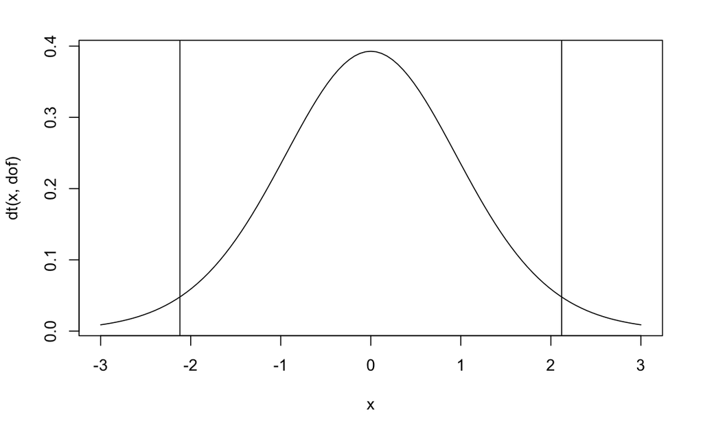

```r
# 上側確率0.975のt値のところにラインを引く
abline(v=qt(0.975, dof))
```

```r
# 両側検定におけるp値を求める
p <- 2*pt(t, dof)

# t.test()でスチューデントのt検定を実施
t.test(menu1, menu2, var.equal = TRUE)
```

```
    Two Sample t-test

data:  menu1 and menu2
t = -1.5796, df = 16, p-value = 0.1338
alternative hypothesis: true difference in means is not equal to 0
95 percent confidence interval:
 -11.710273   1.710273
sample estimates:
mean of x mean of y
     77.5      82.5
```

## 7.3 独立した2群の差のt検定②

#### 7.3.0.1 （分散が等しいと仮定できない場合のウェルチのt検定）

### 7.3.1 ウェルチのt検定で、母分散が等しくない2群の平均を検定する

#### 7.3.1.1 独立した2群の分散が等しいことを前提にしないウェルチのt検定

### 7.3.2 ウェルチのt検定を実施する

### Hint t検定のデフォルトはウェルチのt検定

```r
# 満足度調査.txtをデータフレームに格納
data <- read.delim(
  "data/満足度調査.txt",
  header=TRUE,         # 1行目は列名
  fileEncoding="UTF-8" # 文字コードの変換方式
)

# A店の点数をベクトルに格納
a <- data$A店
# B店の点数を欠損値を除いてからベクトルに格納
b <- data$B店[!is.na(data$B店)]
# サマリを出力
summary(a)
```

```
   Min. 1st Qu.  Median    Mean 3rd Qu.    Max.
   3.00    4.75    8.50    7.00    9.00   10.00
```

```r
summary(b)
```

```
   Min. 1st Qu.  Median    Mean 3rd Qu.    Max.
    4.0     6.0     6.5     6.5     7.0    10.0
```

```r
# A店、B店のデータでウェルチのt検定を実施
t.test(a, b)
```

```
    Welch Two Sample t-test

data:  a and b
t = 0.71122, df = 30.25, p-value = 0.4824
alternative hypothesis: true difference in means is not equal to 0
95 percent confidence interval:
 -0.9352622  1.9352622
sample estimates:
mean of x mean of y
      7.0       6.5
```

## 7.4 対応のある2群の差のt検定

### 7.4.1 対応のある2群の差のt検定は変化量（変量の差）の平均値の検定になる

#### 7.4.1.1 検定統計量tの式

### 7.4.2 検定を実施して平均に差があるのかを判定する

#### 7.4.2.1 検定統計量の実現値を求める

#### 7.4.2.2 平均体重の変化に統計的な差は認められるのか

#### 7.4.2.3 p値を求めてt検定を行う

#### 7.4.2.4 t.test()関数で検定統計量tの実現値を求める

```r
# 体重の変化.txtをデータフレームに格納
data <- read.delim(
  "data/体重の変化.txt",
  header=TRUE,         # 1行目は列名であることを指定
  fileEncoding="UTF-8" # 文字コードをShift_JISに指定
)
# 摂取前の体重をベクトルに格納
before <- data$摂取前
# 摂取後の体重をベクトルに格納
after <- data$摂取後
# 摂取前の体重の平均
mean_m1 <- mean(before)
# 摂取後の体重の平均
mean_m2 <- mean(after)
# 接種後と摂取前の体重の差(変化量)を求める
change <- after - before

# 検定統計量の分母の計算
denom <- sd(change)/sqrt(length(change))
# 検定統計量の分子の計算
numer <- mean(change)
# 検定統計量を求める
t <- numer / denom
# 自由度(n-1)を求める
dof <- length(change) - 1

# 自由度dofのt分布における下側確率0.025の下限信頼限界を求める
t_low <- qt(0.025, dof)
# 自由度dofのt分布における上側確率0.025の上限信頼限界を求める
t_upp <- qt(0.025, dof, lower.tail=FALSE)

# 自由度(n-1)のt分布のグラフを描く
curve(dt(x, dof), -3, 3)

# 下側確率0.025のt値のところにラインを引く
abline(v=qt(0.025, dof))
```

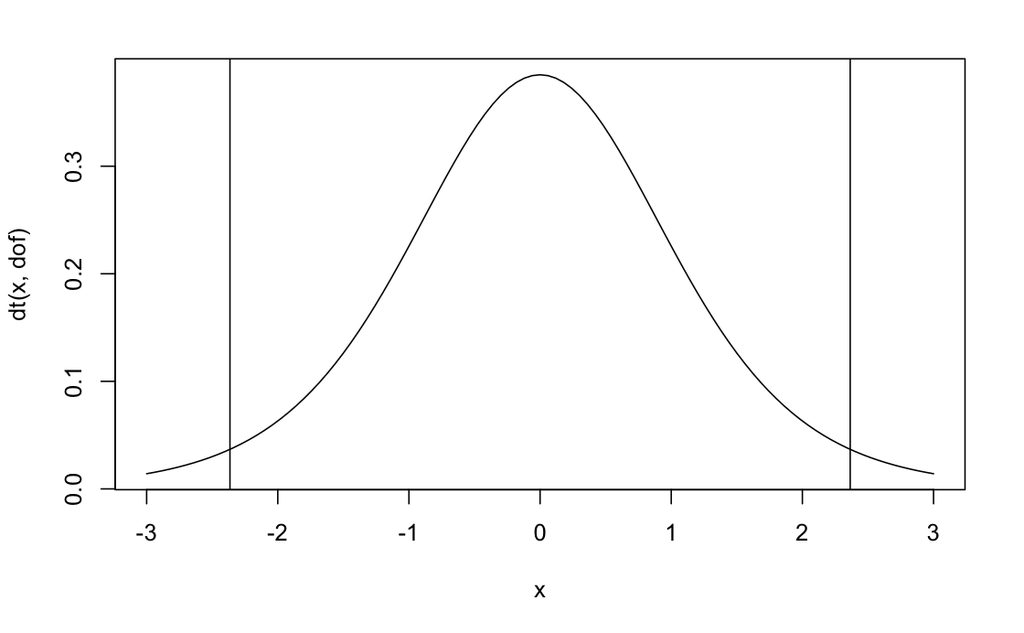

```r
# 上側確率0.975のt値のところにラインを引く
abline(v=qt(0.975, dof))
```

```r
# 両側検定におけるp値を求める
p <- 2*pt(t, dof)

# 変化量を引数にしてt.test()を実行
t.test(change)
```

```
    One Sample t-test

data:  change
t = -3.0551, df = 7, p-value = 0.01845
alternative hypothesis: true mean is not equal to 0
95 percent confidence interval:
 -8.870025 -1.129975
sample estimates:
mean of x
       -5
```

```r
# 接種後のデータと摂取前のデータを指定してt.test()を実行
t.test(after, # 接種後のデータ
  before,     # 摂取前のデータ
  paired=TRUE # 対応ありを指定
  )
```

```
    Paired t-test

data:  after and before
t = -3.0551, df = 7, p-value = 0.01845
alternative hypothesis: true mean difference is not equal to 0
95 percent confidence interval:
 -8.870025 -1.129975
sample estimates:
mean difference
             -5
```

### Memo RStudioの［Packages］ビュー

# 8 3つの平均値が同じ土俵で比較できるか調べる（t検定が使えない場合の分散分析）

## 8.1 1要因の分散分析①（対応なし）

### 8.1.1 t検定は3つ以上の平均の差の検定には使えない

#### 8.1.1.1 t検定が3つ以上の平均の差の検定に使えない理由

### 8.1.2 3つの平均に差があるかを分散分析で調べる

#### 8.1.2.1 分散分析に使用する検定統計量

### Memo 分散分析

### Tips 分子の自由度6、分母の自由度18のF分布をグラフにする

### 8.1.3 1要因の分散分析（対応なし）を実施する

#### 8.1.3.1 分散分析のためのデータを用意する

#### 8.1.3.2 oneway.test()関数で検定統計量とp値を求める

#### 8.1.3.3 aov()関数で検定統計量の実現値とp値を求める

#### 8.1.3.4 anova()関数で検定統計量の実現値とp値を求める

### 8.1.4 分散分析を理解する

#### 8.1.4.1 「群間のズレ」と「群内のズレ」

#### 8.1.4.2 標本平均間のズレと標本内部のデータのズレを見る

### 8.1.5 多重比較（Tukeyの方法）

#### 8.1.5.1 RのTukeyHSD()関数で多重比較を行ってみる

```r
# 模試結果.txtをデータフレームに格納
data <- read.delim(
  "data/模試結果.txt",
  header=TRUE,         # 1行目は列名
  fileEncoding="UTF-8" # 文字コードの変換方式
)

# データフレームの各列のデータをベクトルに代入
variate <- c(data[,1], # 直前対策講座Aのデータ
             data[,2], # 直前対策講座Bのデータ
             data[,3]) # 直前対策講座Cのデータ

# 各列のサイズを取得
col_1 <- length(data[,1])
col_2 <- length(data[,2])
col_3 <- length(data[,3])

# 列名を列データの数だけ格納したベクトルをfactor型に変換
fact <- factor(
  c(rep(colnames(data)[1], col_1), # "直前対策講座A"×20
    rep(colnames(data)[2], col_2), # "直前対策講座B"×20
    rep(colnames(data)[3], col_3)) # "直前対策講座C"×20
  )

# oneway.test()で1要因の分散分析(対応なし)を実施
oneway.test(
  variate~fact,   # variateにfactを対応付けるモデル式
  var.equal=TRUE # 分散には等質性あると仮定
  )
```

```
    One-way analysis of means

data:  variate and fact
F = 6.8174, num df = 2, denom df = 57, p-value = 0.002215
```

```r
# aov()を実行
aov(variate~fact)
```

```
Call:
   aov(formula = variate ~ fact)

Terms:
                    fact Residuals
Sum of Squares   805.833  3368.750
Deg. of Freedom        2        57

Residual standard error: 7.687709
Estimated effects may be unbalanced
```

```r
# summary()関数の引数にaov()関数の実行結果を指定
summary(aov(variate~fact))
```

```
            Df Sum Sq Mean Sq F value  Pr(>F)
fact         2    806   402.9   6.817 0.00222 **
Residuals   57   3369    59.1
---
Signif. codes:  0 ‘***’ 0.001 ‘**’ 0.01 ‘*’ 0.05 ‘.’ 0.1 ‘ ’ 1
```

```r
# anova()を実行
anova(lm(variate~fact))
```

```
Analysis of Variance Table

Response: variate
          Df Sum Sq Mean Sq F value   Pr(>F)
fact       2  805.8  402.92  6.8174 0.002215 **
Residuals 57 3368.8   59.10
---
Signif. codes:  0 ‘***’ 0.001 ‘**’ 0.01 ‘*’ 0.05 ‘.’ 0.1 ‘ ’ 1
```

```r
# Tukeyの方法で多重比較を行う
TukeyHSD(aov(variate~fact))
```

```
  Tukey multiple comparisons of means
    95% family-wise confidence level

Fit: aov(formula = variate ~ fact)

$fact
                            diff        lwr       upr     p adj
直前対策講座B-直前対策講座A 6.75  0.8998358 12.600164 0.0199934
直前対策講座C-直前対策講座A 8.50  2.6498358 14.350164 0.0026126
直前対策講座C-直前対策講座B 1.75 -4.1001642  7.600164 0.7528036
```

```r
# 模試結果.txtをデータフレームに格納
data <- read.delim(
  "data/模試結果.txt",
  header=TRUE,         # 1行目は列名
  fileEncoding="UTF-8" # 文字コードの変換方式
)

# 分散を返す関数
getDisper <- function(x) {
  dev <- x - mean(x)
  return(sum(dev^2) / length(x))
}

# データフレームの各列のデータをベクトルに代入
variate <- c(data[,1], # 直前対策講座Aのデータ
             data[,2], # 直前対策講座Bのデータ
             data[,3]) # 直前対策講座Cのデータ

# 各列のサイズを取得
col_1 <- length(data[,1])
col_2 <- length(data[,2])
col_3 <- length(data[,3])

# 3群それぞれの平均を求める
m_A <- mean(data[,1])
m_B <- mean(data[,2])
m_C <- mean(data[,3])
# 3群の平均を求める
m_all <- mean(variate)

# 群間の平方和を求める
cohort_s_sum <- sum((m_A - m_all)^2*col_1,
                    (m_B - m_all)^2*col_2,
                    (m_C - m_all)^2*col_3)

# 群内の平方和を求める
cohort_in_s_sum <- sum(getDisper(data[,1])*col_1,
                       getDisper(data[,2])*col_2,
                       getDisper(data[,3])*col_3)

# 群間の不偏分散
cohort_unbiased <- cohort_s_sum/(length(data[1,]) - 1)

# 群内の不偏分散
cohort_in_unbiased <- cohort_in_s_sum/((col_1-1) + (col_2-1) + (col_3-1))

# 検定統計量F
f <- cohort_unbiased/cohort_in_unbiased
```

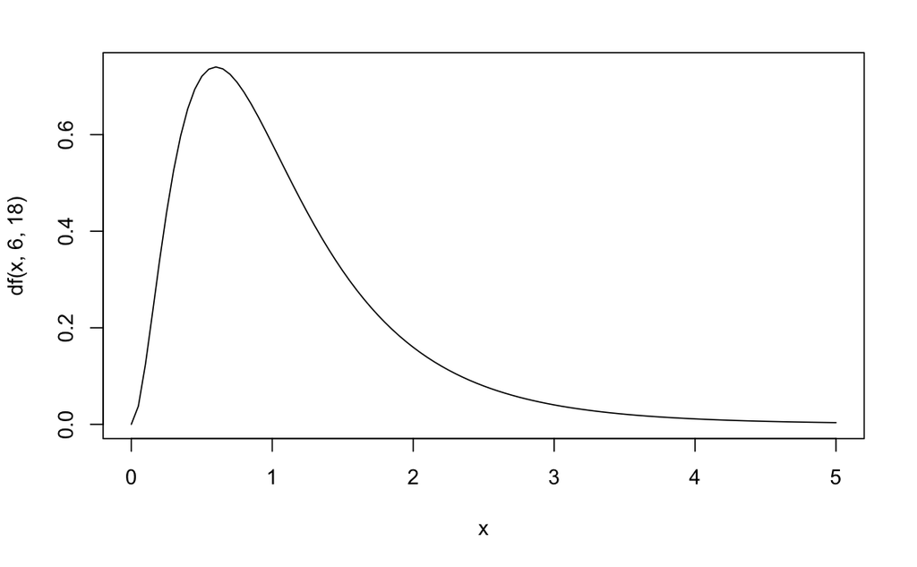

```r
curve(df(x, 6, 18), 0, 5)
```

## 8.2 1要因の分散分析②（対応あり）

### 8.2.1 対応がある1要因の分散分析の実施

#### 8.2.1.1 分散分析の実施

### 8.2.2 対応ありとなしで違いが出たのはなぜ？

#### 8.2.2.1 対応なしと対応ありによる違いを見る

#### 8.2.2.2 平方和を分解して自由度を計算してみよう

```r
# 同一の受講生による模試結果.txtをデータフレームに格納
data <- read.delim(
  "data/同一の受講生による模試結果.txt",
  header=TRUE,         # 1行目は列名
  fileEncoding="UTF-8" # 文字コードの変換方式
)

# データフレームの各列のデータをベクトルに代入
variate <- c(data[,2], # 直前対策講座Aのデータ
             data[,3], # 直前対策講座Bのデータ
             data[,4]) # 直前対策講座Cのデータ

# 各列のサイズを取得
col_1 <- length(data[,2])
col_2 <- length(data[,3])
col_3 <- length(data[,4])

# 列名を列データの数だけ格納したベクトルをfactor型に変換
fact <- factor(
  c(rep(colnames(data)[2], col_1), # "直前対策講座A"×20
    rep(colnames(data)[3], col_2), # "直前対策講座B"×20
    rep(colnames(data)[4], col_3)) # "直前対策講座C"×20
  )

# 20人を識別するA～Tを3個作成し、factor型に変換
id <- factor(rep(data[,1], # A～Tが入力されている列
                 length(data[1,]) - 1) # 列数4から1を引く
             )

# aov()をsummary()の引数にして実行
# fact+Noで各講座受講後の得点を受講者に対応付ける
summary(
  aov(variate~fact+id))
```

```
            Df Sum Sq Mean Sq F value  Pr(>F)
fact         2  805.8   402.9   7.490 0.00181 **
id          19 1324.6    69.7   1.296 0.24215
Residuals   38 2044.2    53.8
---
Signif. codes:  0 ‘***’ 0.001 ‘**’ 0.01 ‘*’ 0.05 ‘.’ 0.1 ‘ ’ 1
```

```r
# ---------------------------------------------------
# 平方和の分解
# ---------------------------------------------------

# 3講座受講後の得点を(20,3)の行列にする
all <- matrix(variate, nrow=20, ncol=3)
# 講座ごとの平均点を求める
point_mean <- colMeans(all)
# 受講者ごとに３講座の平均点を求める
person_mean <- rowMeans(all)
# ３講座受講後のすべての得点について平均点を求める
all_mean <- mean(all)
# 出力
all
```

```
      [,1] [,2] [,3]
 [1,]   65   90   85
 [2,]   60   75   65
 [3,]   75   70   90
 [4,]   80   90   75
 [5,]   65   65   90
 [6,]   60   70   75
 [7,]   70   80   85
 [8,]   85   85   75
 [9,]   65   70   95
[10,]   75   70   75
[11,]   75   85   80
[12,]   70   75   75
[13,]   80   80   85
[14,]   75   90   75
[15,]   80   80   85
[16,]   80   90   90
[17,]   65   85   90
[18,]   70   85   80
[19,]   75   75   75
[20,]   80   75   75
```

```r
point_mean
```

```
[1] 72.50 79.25 81.00
```

```r
person_mean
```

```
 [1] 80.00000 66.66667 78.33333 81.66667 73.33333 68.33333 78.33333 81.66667 76.66667 73.33333
[11] 80.00000 73.33333 81.66667 80.00000 81.66667 86.66667 80.00000 78.33333 75.00000 76.66667
```

```r
all_mean
```

```
[1] 77.58333
```

```r
# 全体の平均点を(20,3)の行列にする
all_mean_matrix <- matrix(
  rep(all_mean, 60), nrow = 20, ncol = 3)
# 講座ごとの平均点を(20,3)の行列にする
point_mean_matrix <- matrix(
  rep(point_mean, 20), nrow = 20, ncol = 3, byrow = TRUE)
# 受講者の3講座の平均点を(20,3)の行列にする
person_mean_matrix <- matrix(
  rep(person_mean, 3), nrow = 20, ncol = 3)
# 出力
all_mean_matrix
```

```
          [,1]     [,2]     [,3]
 [1,] 77.58333 77.58333 77.58333
 [2,] 77.58333 77.58333 77.58333
 [3,] 77.58333 77.58333 77.58333
 [4,] 77.58333 77.58333 77.58333
 [5,] 77.58333 77.58333 77.58333
 [6,] 77.58333 77.58333 77.58333
 [7,] 77.58333 77.58333 77.58333
 [8,] 77.58333 77.58333 77.58333
 [9,] 77.58333 77.58333 77.58333
[10,] 77.58333 77.58333 77.58333
[11,] 77.58333 77.58333 77.58333
[12,] 77.58333 77.58333 77.58333
[13,] 77.58333 77.58333 77.58333
[14,] 77.58333 77.58333 77.58333
[15,] 77.58333 77.58333 77.58333
[16,] 77.58333 77.58333 77.58333
[17,] 77.58333 77.58333 77.58333
[18,] 77.58333 77.58333 77.58333
[19,] 77.58333 77.58333 77.58333
[20,] 77.58333 77.58333 77.58333
```

```r
point_mean_matrix
```

```
      [,1]  [,2] [,3]
 [1,] 72.5 79.25   81
 [2,] 72.5 79.25   81
 [3,] 72.5 79.25   81
 [4,] 72.5 79.25   81
 [5,] 72.5 79.25   81
 [6,] 72.5 79.25   81
 [7,] 72.5 79.25   81
 [8,] 72.5 79.25   81
 [9,] 72.5 79.25   81
[10,] 72.5 79.25   81
[11,] 72.5 79.25   81
[12,] 72.5 79.25   81
[13,] 72.5 79.25   81
[14,] 72.5 79.25   81
[15,] 72.5 79.25   81
[16,] 72.5 79.25   81
[17,] 72.5 79.25   81
[18,] 72.5 79.25   81
[19,] 72.5 79.25   81
[20,] 72.5 79.25   81
```

```r
person_mean_matrix
```

```
          [,1]     [,2]     [,3]
 [1,] 80.00000 80.00000 80.00000
 [2,] 66.66667 66.66667 66.66667
 [3,] 78.33333 78.33333 78.33333
 [4,] 81.66667 81.66667 81.66667
 [5,] 73.33333 73.33333 73.33333
 [6,] 68.33333 68.33333 68.33333
 [7,] 78.33333 78.33333 78.33333
 [8,] 81.66667 81.66667 81.66667
 [9,] 76.66667 76.66667 76.66667
[10,] 73.33333 73.33333 73.33333
[11,] 80.00000 80.00000 80.00000
[12,] 73.33333 73.33333 73.33333
[13,] 81.66667 81.66667 81.66667
[14,] 80.00000 80.00000 80.00000
[15,] 81.66667 81.66667 81.66667
[16,] 86.66667 86.66667 86.66667
[17,] 80.00000 80.00000 80.00000
[18,] 78.33333 78.33333 78.33333
[19,] 75.00000 75.00000 75.00000
[20,] 76.66667 76.66667 76.66667
```

```r
# すべての得点について偏差を求める
all_dev <- all - all_mean_matrix
# 出力
all_dev
```

```
            [,1]       [,2]       [,3]
 [1,] -12.583333  12.416667   7.416667
 [2,] -17.583333  -2.583333 -12.583333
 [3,]  -2.583333  -7.583333  12.416667
 [4,]   2.416667  12.416667  -2.583333
 [5,] -12.583333 -12.583333  12.416667
 [6,] -17.583333  -7.583333  -2.583333
 [7,]  -7.583333   2.416667   7.416667
 [8,]   7.416667   7.416667  -2.583333
 [9,] -12.583333  -7.583333  17.416667
[10,]  -2.583333  -7.583333  -2.583333
[11,]  -2.583333   7.416667   2.416667
[12,]  -7.583333  -2.583333  -2.583333
[13,]   2.416667   2.416667   7.416667
[14,]  -2.583333  12.416667  -2.583333
[15,]   2.416667   2.416667   7.416667
[16,]   2.416667  12.416667  12.416667
[17,] -12.583333   7.416667  12.416667
[18,]  -7.583333   7.416667   2.416667
[19,]  -2.583333  -2.583333  -2.583333
[20,]   2.416667  -2.583333  -2.583333
```

```r
# 条件として模擬試験ごとの効果を求める
terms <- point_mean_matrix - all_mean_matrix
# 出力
terms
```

```
           [,1]     [,2]     [,3]
 [1,] -5.083333 1.666667 3.416667
 [2,] -5.083333 1.666667 3.416667
 [3,] -5.083333 1.666667 3.416667
 [4,] -5.083333 1.666667 3.416667
 [5,] -5.083333 1.666667 3.416667
 [6,] -5.083333 1.666667 3.416667
 [7,] -5.083333 1.666667 3.416667
 [8,] -5.083333 1.666667 3.416667
 [9,] -5.083333 1.666667 3.416667
[10,] -5.083333 1.666667 3.416667
[11,] -5.083333 1.666667 3.416667
[12,] -5.083333 1.666667 3.416667
[13,] -5.083333 1.666667 3.416667
[14,] -5.083333 1.666667 3.416667
[15,] -5.083333 1.666667 3.416667
[16,] -5.083333 1.666667 3.416667
[17,] -5.083333 1.666667 3.416667
[18,] -5.083333 1.666667 3.416667
[19,] -5.083333 1.666667 3.416667
[20,] -5.083333 1.666667 3.416667
```

```r
# 受講者の平均点から講座ごとの平均点を引いて
# 受講者ごとの効果を求める
person <- person_mean_matrix - all_mean_matrix
# 出力
person
```

```
             [,1]        [,2]        [,3]
 [1,]   2.4166667   2.4166667   2.4166667
 [2,] -10.9166667 -10.9166667 -10.9166667
 [3,]   0.7500000   0.7500000   0.7500000
 [4,]   4.0833333   4.0833333   4.0833333
 [5,]  -4.2500000  -4.2500000  -4.2500000
 [6,]  -9.2500000  -9.2500000  -9.2500000
 [7,]   0.7500000   0.7500000   0.7500000
 [8,]   4.0833333   4.0833333   4.0833333
 [9,]  -0.9166667  -0.9166667  -0.9166667
[10,]  -4.2500000  -4.2500000  -4.2500000
[11,]   2.4166667   2.4166667   2.4166667
[12,]  -4.2500000  -4.2500000  -4.2500000
[13,]   4.0833333   4.0833333   4.0833333
[14,]   2.4166667   2.4166667   2.4166667
[15,]   4.0833333   4.0833333   4.0833333
[16,]   9.0833333   9.0833333   9.0833333
[17,]   2.4166667   2.4166667   2.4166667
[18,]   0.7500000   0.7500000   0.7500000
[19,]  -2.5833333  -2.5833333  -2.5833333
[20,]  -0.9166667  -0.9166667  -0.9166667
```

```r
# 残差を求める
residual <- all - all_mean_matrix - terms - person
# 出力
residual
```

```
             [,1]       [,2]         [,3]
 [1,] -9.91666667   8.333333   1.58333333
 [2,] -1.58333333   6.666667  -5.08333333
 [3,]  1.75000000 -10.000000   8.25000000
 [4,]  3.41666667   6.666667 -10.08333333
 [5,] -3.25000000 -10.000000  13.25000000
 [6,] -3.25000000   0.000000   3.25000000
 [7,] -3.25000000   0.000000   3.25000000
 [8,]  8.41666667   1.666667 -10.08333333
 [9,] -6.58333333  -8.333333  14.91666667
[10,]  6.75000000  -5.000000  -1.75000000
[11,]  0.08333333   3.333333  -3.41666667
[12,]  1.75000000   0.000000  -1.75000000
[13,]  3.41666667  -3.333333  -0.08333333
[14,]  0.08333333   8.333333  -8.41666667
[15,]  3.41666667  -3.333333  -0.08333333
[16,] -1.58333333   1.666667  -0.08333333
[17,] -9.91666667   3.333333   6.58333333
[18,] -3.25000000   5.000000  -1.75000000
[19,]  5.08333333  -1.666667  -3.41666667
[20,]  8.41666667  -3.333333  -5.08333333
```

```r
# すべての得点について偏差の平方和を求める
all_square_sum <- sum(all_dev^2)
# 模擬試験ごとの効果の平方和を求める
terms_square_sum <- sum(terms^2)
# 受講者ごとの効果の平方和を求める
person_square_sum <- sum(person^2)
# 残差の平方和を求める
residual_square_sum <- sum(residual^2)

# 出力
all_square_sum
```

```
[1] 4174.583
```

```r
terms_square_sum
```

```
[1] 805.8333
```

```r
person_square_sum
```

```
[1] 1324.583
```

```r
residual_square_sum
```

```
[1] 2044.167
```

```r
# 模擬試験ごとの効果の平方和+受講者ごとの効果の平方和+残差の平方和
terms_square_sum + person_square_sum + residual_square_sum
```

```
[1] 4174.583
```

## 8.3 2要因の分散分析①（2要因とも対応なし）

### 8.3.1 主効果と交互に作用する効果

#### 8.3.1.1 主効果と交互作用効果について

### 8.3.2 2要因の分散分析（対応なし）を実施する

#### 8.3.2.1 2要因の分散分析（対応なし）の実施

#### 8.3.2.2 帰無仮説の棄却／採択の決定

#### 8.3.2.3 交互作用効果を確認する

```r
# 学習効果.txtをデータフレームに格納
data <- read.delim(
  "data/学習効果.txt",
  header=TRUE,         # 1行目は列名
  fileEncoding="UTF-8" # 文字コードの変換方式
)

# データフレームの各列のデータを1つのベクトルに格納
variate <- c(data[,1], # 1列目のデータ
             data[,2], # 2列目のデータ
             data[,3], # 3列目のデータ
             data[,4], # 4列目のデータ
             data[,5], # 5列目のデータ
             data[,6]) # 6列目のデータ


# 1要因あたりのデータ数(15)を取得
size <- length(data[,1])*length(colnames(data))/2
# 1列あたりのデータ数(5)を取得
size_col <- length(data[,1])

# 1つ目の要因の水準(朝と夜)を識別子fac_A_1、fac_A_2
# として、それぞれデータの数(15)だけ作成
fac1 <- factor(
  c(rep("fac_A_1", size), # 1つ目の要因の水準
    rep("fac_A_2", size)) # 2つ目の要因の水準
  )

# 2つ目の要因の水準(英、漢字、古文)を識別子fac_B_1、fac_B_2、fac_B_3
# として行データの数×2セット(朝と夜)作成
fac2 <- factor(
  rep(                          # 以下を2セット作成
    c(rep("fac_B_1", size_col), # 「英単語」の識別子×行データの数
      rep("fac_B_2", size_col), # 「漢字」の識別子×行データの数
      rep("fac_B_3", size_col)) # 「古文」の識別子×行データの数
    ,2)
  )

# aov()関数を実行して分散分析表を出力
summary(
  aov(variate ~ fac1*fac2))
```

```
            Df Sum Sq Mean Sq F value   Pr(>F)
fac1         1  73.63   73.63  24.820 4.35e-05 ***
fac2         2 143.27   71.63  24.146 1.79e-06 ***
fac1:fac2    2  11.27    5.63   1.899    0.172
Residuals   24  71.20    2.97
---
Signif. codes:  0 ‘***’ 0.001 ‘**’ 0.01 ‘*’ 0.05 ‘.’ 0.1 ‘ ’ 1
```

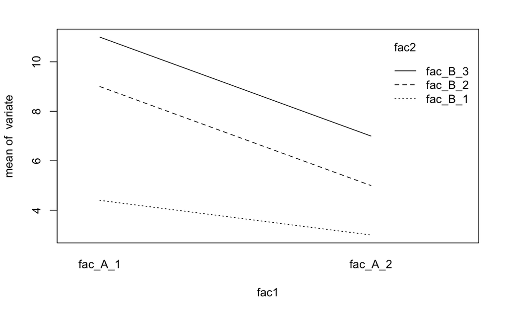

```r
# 「学習する時間」「学習内容」のそれぞれの水準を組み合わせたグラフを出力
interaction.plot(fac1, fac2, variate)
```

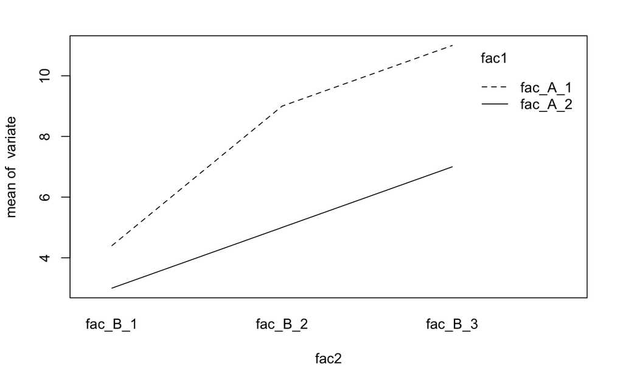

```r
interaction.plot(fac2, fac1, variate)
```

## 8.4 2要因の分散分析②（2要因とも対応あり）

### 8.4.1 2要因の分散分析（対応あり）を実施する

#### 8.4.1.1 2要因の分散分析（対応あり）の実施

#### 8.4.1.2 Onepoint 2要因の分散分析（対応あり）を行ったあとは

```r
# 学習効果.txtをデータフレームに格納
data <- read.delim(
  "data/学習効果2.txt",
  header=TRUE,         # 1行目は列名
  fileEncoding="UTF-8" # 文字コードの変換方式
)

# データフレームの被験者以外の列データをベクトルに格納
variate <- c(data[,2],
             data[,3],
             data[,4],
             data[,5],
             data[,6],
             data[,7]
             )

# 1要因に含まれるデータ数を取得
size <- length(data[,1])*(length(colnames(data)) - 1)/2
# 1列あたりのデータ数を取得
size_col <- length(data[,1])
# 条件の数を取得(被験者の列を除く)
size_row <- length(colnames(data)) - 1

# 1つ目の要因の水準(朝と夜)を識別子fac_A_1、fac_A_2として、
# それぞれデータの数(15)だけ作成
fac1 <- factor(
  c(rep("fac_A_1", size), # 1つ目の要因の水準
    rep("fac_A_2", size)) # 2つ目の要因の水準
  )

# 2つ目の要因の水準(英、漢字、古文)を識別子を
# 行データの数×2セット(朝と夜)作成
fac2 <- factor(
  rep(                          # 以下を2セット作成
    c(rep("fac_B_1", size_col), # 「英単語」の識別子×行データの数
      rep("fac_B_2", size_col), # 「漢字」の識別子×行データの数
      rep("fac_B_3", size_col)) # 「古文」の識別子×行データの数
    ,2))

# 5名の被験者の識別子を要因の数(6)だけ作成
fac3 <- factor(
  rep(c("fac_C_1",  # 1人目
        "fac_C_2",  # 2人目
        "fac_C_3",  # 3人目
        "fac_C_4",  # 4人目
        "fac_C_5")  # 5人目
      ,6))

# aov()関数を実行して分散分析表を出力
summary(
  aov(variate ~ fac1*fac2 + Error(fac3 +
                                  fac3 : fac1 +
                                  fac3 : fac2 +
                                  fac1 : fac2 : fac3)))
```

```
Error: fac3
          Df Sum Sq Mean Sq F value Pr(>F)
Residuals  4  39.53   9.883

Error: fac3:fac1
          Df Sum Sq Mean Sq F value Pr(>F)
fac1       1  73.63   73.63    16.8 0.0149 *
Residuals  4  17.53    4.38
---
Signif. codes:  0 ‘***’ 0.001 ‘**’ 0.01 ‘*’ 0.05 ‘.’ 0.1 ‘ ’ 1

Error: fac3:fac2
          Df Sum Sq Mean Sq F value   Pr(>F)
fac2       2 143.27   71.63   113.1 1.36e-06 ***
Residuals  8   5.07    0.63
---
Signif. codes:  0 ‘***’ 0.001 ‘**’ 0.01 ‘*’ 0.05 ‘.’ 0.1 ‘ ’ 1

Error: fac3:fac1:fac2
          Df Sum Sq Mean Sq F value Pr(>F)
fac1:fac2  2 11.267   5.633   4.971 0.0395 *
Residuals  8  9.067   1.133
---
Signif. codes:  0 ‘***’ 0.001 ‘**’ 0.01 ‘*’ 0.05 ‘.’ 0.1 ‘ ’ 1
```

## 8.5 2要因の分散分析③（1要因のみ対応あり）

### 8.5.1 2要因の分散分析（1要因のみ対応あり）を実施する

#### 8.5.1.1 2要因の分散分析（1要因のみ対応あり）の実施

#### 8.5.1.2 帰無仮説の棄却／採択の決定

```r
# 学習効果_1要因のみ対応.txtをデータフレームに格納
data <- read.delim(
  "data/学習効果_1要因のみ対応.txt",
  header=TRUE,         # 1行目は列名
  fileEncoding="UTF-8" # 文字コードの変換方式
)

# データフレームのデータの列のみをベクトルに格納
variate <- c(
  data[,2],  # 2列目
  data[,3],  # 3列目
  data[,4],  # 4列目
  data[,6],  # 6列目
  data[,7],  # 7列目
  data[,8])  # 8列目


# 1要因に含まれるデータの数を取得
size <- length(data[,1]) * (length(colnames(data)) - 2)/2
# 1列あたりのデータ数を取得
size_col <- length(data[,1])
# 条件の数を取得(被験者の2列を除く)
size_row <- length(colnames(data)) - 2

# 1つ目の要因の水準(朝と夜)を識別子fac_A_1、fac_A_2として、
# それぞれデータの数(15)だけ作成
fac1 <- factor(
  c(rep("fac_A_1", size), # 1つ目の要因の水準
    rep("fac_A_2", size)) # 2つ目の要因の水準
)

# 2つ目の要因の水準(英、漢字、古文)を識別子を
# 行データの数×2セット(朝と夜)作成
fac2 <- factor(
  rep(                          # 以下を2セット作成
    c(rep("fac_B_1", size_col), # 「英単語」の識別子×行データの数
      rep("fac_B_2", size_col), # 「漢字」の識別子×行データの数
      rep("fac_B_3", size_col)) # 「古文」の識別子×行データの数
    ,2))

# 朝の被験者と夜の被験者の識別子を作成
fac3 <- factor(
  c(
    # 朝学習した5人を分類する識別子1～5を水準の数(3)だけ作成
    rep(1:size_col, size_row/2),
    # 夜学習した5人を分類する識別子6～10を水準の数(3)だけ作成
    rep(size_row:(size_col*2), size_row/2)
  )
)

# aov()関数を実行して分散分析表を出力
summary(
  aov(variate ~ fac1*fac2 + Error(fac3 : fac1 +
                                  fac3 : fac1 : fac2)))
```

```
Error: fac3:fac1
          Df Sum Sq Mean Sq F value Pr(>F)
fac1       1  73.63   73.63   10.32 0.0124 *
Residuals  8  57.07    7.13
---
Signif. codes:  0 ‘***’ 0.001 ‘**’ 0.01 ‘*’ 0.05 ‘.’ 0.1 ‘ ’ 1

Error: fac3:fac1:fac2
          Df Sum Sq Mean Sq F value   Pr(>F)
fac2       2 143.27   71.63  81.094 4.23e-09 ***
fac1:fac2  2  11.27    5.63   6.377  0.00919 **
Residuals 16  14.13    0.88
---
Signif. codes:  0 ‘***’ 0.001 ‘**’ 0.01 ‘*’ 0.05 ‘.’ 0.1 ‘ ’ 1
```

### Hint 帰無仮説と対立仮説

# 9 回帰分析で未来を知る（単回帰分析と重回帰分析）

## 9.1 清涼飲料水の売上と気温の関係（相関関係と線形単回帰分析）

### 9.1.1 データ間の相関関係を分析する

#### 9.1.1.1 相関分析でデータ同士の関係性を数値化する

### Hint 相関分析のポイントと注意点

### 9.1.2 散布図で相関関係を見る（散布図の描画）

#### 9.1.2.1 散布図の作成

### 9.1.3 2つのデータの関係の強さを求める（相関係数の計算）

#### 9.1.3.1 2つのデータの相関係数を求める

### Memo シグマの記号について

### 9.1.4 線形回帰分析を実行する

#### 9.1.4.1 回帰式における回帰係数と定数項を求める

#### 9.1.4.2 回帰係数と共分散の関係を見る

#### 9.1.4.3 Im()関数で線形回帰分析を行う

### 9.1.5 最高気温が1℃上昇したときの売上数を予測する

#### 9.1.5.1 回帰直線を散布図上に表示してみる

#### 9.1.5.2 最高気温が30℃、31℃、さらに36℃のときの売上数を予測する

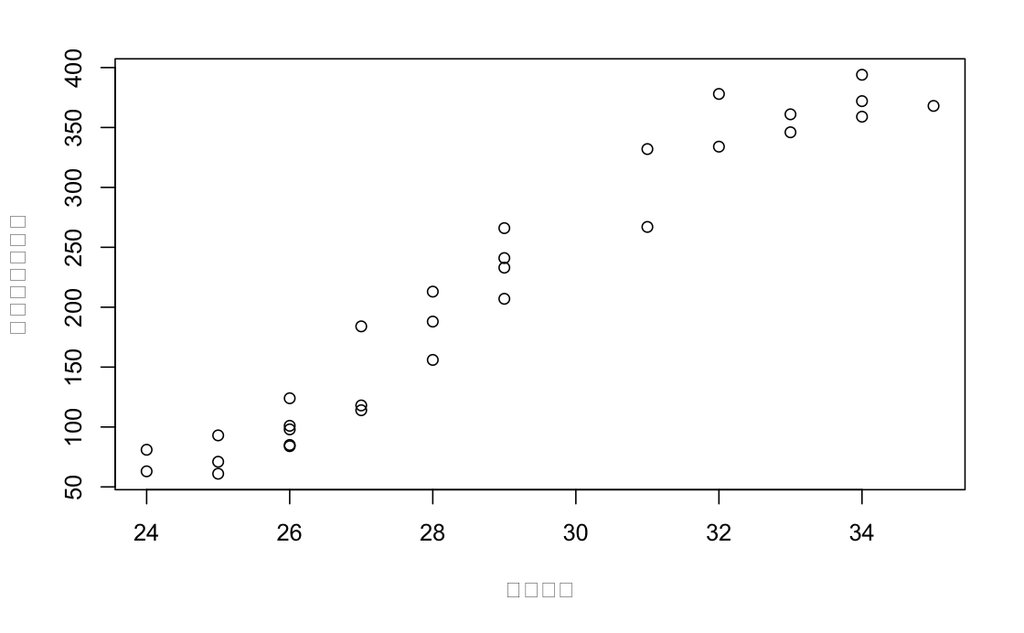

```r
# 清涼飲料水売上.txtをデータフレームに格納
data <- read.delim(
  file="data/清涼飲料水売上.txt",
  header=TRUE,         # 1行目は列名
  fileEncoding="UTF-8" # 文字コードの変換方式
)

# 散布図を描く
plot(data)
```

```r
# 相関係数を求める
cor(data["最高気温"], data["清涼飲料売上数"])
```

```
         清涼飲料売上数
最高気温      0.9702484
```

```r
# 線形単回帰分析を実行
result <- lm("清涼飲料売上数 ~ 最高気温", data=data)
# 分析結果を出力
summary(result)
```

```
Call:
lm(formula = "清涼飲料売上数 ~ 最高気温", data = data)

Residuals:
    Min      1Q  Median      3Q     Max
-52.051 -20.828  -1.217  15.338  59.171

Coefficients:
            Estimate Std. Error t value Pr(>|t|)
(Intercept) -760.877     46.071  -16.52 5.75e-16 ***
最高気温      33.741      1.591   21.20  < 2e-16 ***
---
Signif. codes:  0 ‘***’ 0.001 ‘**’ 0.01 ‘*’ 0.05 ‘.’ 0.1 ‘ ’ 1

Residual standard error: 28.7 on 28 degrees of freedom
Multiple R-squared:  0.9414,    Adjusted R-squared:  0.9393
F-statistic: 449.7 on 1 and 28 DF,  p-value: < 2.2e-16
```

```r
# 分析結果から定数項と回帰係数のみを出力する
round(
  coefficients(result), 2) # 小数点以下2桁で丸める
```

```
(Intercept)    最高気温
    -760.88       33.74
```

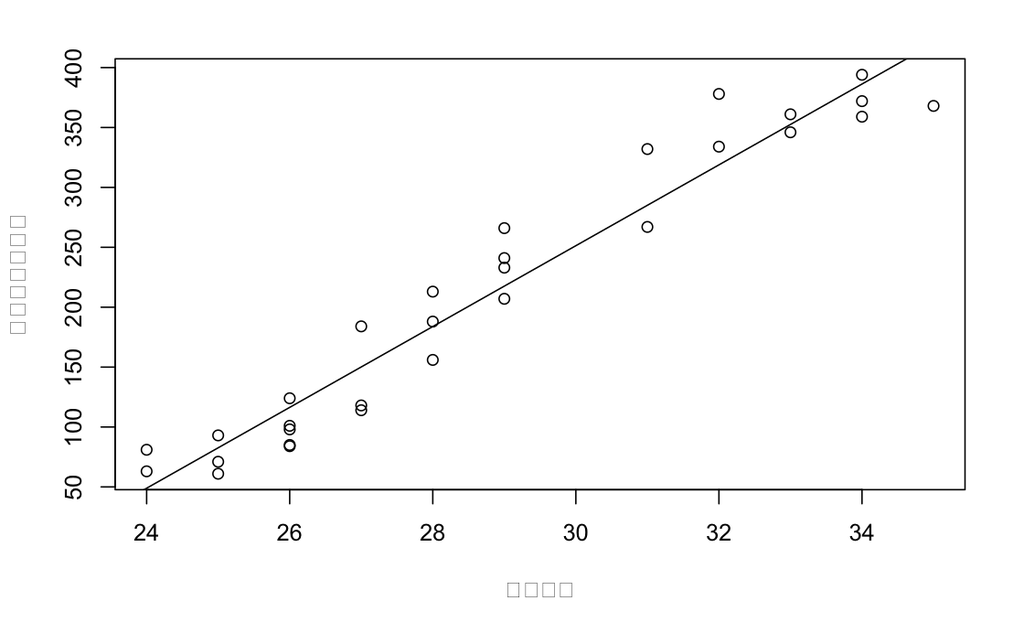

```r
# 散布図を描画して回帰直線を引く
plot(data)
abline(result)
```

```r
# 最高気温が30度のときの売上数を予測する
-760.877 + 33.741*30
```

```
[1] 251.353
```

```r
# 最高気温が31度のときの売上数を予測する
-760.877 + 33.741*31
```

```
[1] 285.094
```

```r
# 最高気温が36度のときの売上数を予測する
-760.877 + 33.741*36
```

```
[1] 453.799
```

```r
# 予測に用いる最高気温をデータフレームに格納
test <- data.frame(
  "最高気温" = c(30, 31, 36)
)

# 分析結果(モデル)を用いて予測する
predict(result, newdata =test)
```

```
       1        2        3
251.3470 285.0878 453.7918
```

```r
# もとのデータと予測値、残差を一覧にする
exp <- fitted(result)              # 元データに対する予測値
res <- residuals(result)           # データと予測値の残差
view <- data.frame(data, exp, res) # データフレームにまとめる
```

### Memo 回帰分析の手法

### Memo 内挿と外挿

### Tips 分析の元データと予測値、残差を一覧で表示する

## 9.2 立地、面積、競合店とアンケート結果から売上を予測する

#### 9.2.0.1 （線形重回帰分析）

### 9.2.1 重回帰分析で説明変数が複数の場合の分析を行う

#### 9.2.1.1 2つ以上の要因を使って予測を行う重回帰分析

#### 9.2.1.2 予測値を示す重回帰分析の式とは

#### 9.2.1.3 相関係数を確認する

### 9.2.2 すべての説明変数を使って重回帰分析する

#### 9.2.2.1 データにあるすべての説明変数を重回帰分析にかける

#### 9.2.2.2 分析結果の見るべきポイントは3つ

### 9.2.3 説明変数を減らしてもう一度分析する

#### 9.2.3.1 step()関数で説明変数を1つずつ減らした分析結果を見る

### Hint 多重共線性

#### 9.2.3.2 2つの説明変数を減らして重回帰分析を実行する

### 9.2.4 説明変数を減らさずに変数の交互作用だけを減らして分析する

#### 9.2.4.1 交互作用を考慮した回帰係数を求める

#### 9.2.4.2 step()関数でAICが最も低い組み合わせを調べる

```r
# 売上高と各種要因.txtをデータフレームに格納
data <- read.delim(
  "data/売上高と各種要因.txt",
  header=TRUE,         # 1行目は列名
  row.names=1,         # 1列目は行名
  fileEncoding="UTF-8" # 文字コードの変換方式
)

# すべてのデータ(説明変数)について相関係数を求める
coef <- cor(data)

# 線形重回帰分析を実行
model <- lm(
  "売上高 ~ 駅からの距離 + 競合店 + 店舗面積 + サービス満足度 + 商品の充実度",
  data=data)
# 分析結果を表示
summary(model)
```

```
Call:
lm(formula = "売上高 ~ 駅からの距離 + 競合店 + 店舗面積 + サービス満足度 + 商品の充実度",
    data = data)

Residuals:
     Min       1Q   Median       3Q      Max
-1989.33  -665.54   -14.47   740.33  1599.93

Coefficients:
               Estimate Std. Error t value Pr(>|t|)
(Intercept)     265.898   2607.724   0.102    0.920
駅からの距離   -171.774    553.409  -0.310    0.761
競合店         -336.777    655.910  -0.513    0.616
店舗面積         -3.213      5.806  -0.553    0.589
サービス満足度 1369.413    494.022   2.772    0.015 *
商品の充実度    968.344    511.048   1.895    0.079 .
---
Signif. codes:  0 ‘***’ 0.001 ‘**’ 0.01 ‘*’ 0.05 ‘.’ 0.1 ‘ ’ 1

Residual standard error: 1104 on 14 degrees of freedom
Multiple R-squared:  0.8077,    Adjusted R-squared:  0.7391
F-statistic: 11.76 on 5 and 14 DF,  p-value: 0.0001312
```

```r
# 係数を表示
round(coefficients(model), 3)
```

```
   (Intercept)   駅からの距離         競合店       店舗面積 サービス満足度   商品の充実度
       265.898       -171.774       -336.777         -3.213       1369.413        968.344
```

```r
# 分析に使用したデータの予測値を取得
exp <- fitted(model)
# 実際の売上高と予測値との誤差を取得
res <- round(residuals(model), 3)
# 実際の売上高と予測値、誤差をデータフレームにまとめる
view <- data.frame(data[1], exp, res)

#########################################
# 説明変数を絞り込んだ重回帰分析
#########################################
# 説明変数を減らしたAIC値を求める
step(model)
```

```
Start:  AIC=285.15
売上高 ~ 駅からの距離 + 競合店 + 店舗面積 + サービス満足度 +
    商品の充実度

                 Df Sum of Sq      RSS    AIC
- 駅からの距離    1    117500 17191813 283.28
- 競合店          1    321523 17395836 283.52
- 店舗面積        1    373505 17447817 283.58
<none>                        17074312 285.15
- 商品の充実度    1   4378764 21453076 287.71
- サービス満足度  1   9371123 26445435 291.90

Step:  AIC=283.28
売上高 ~ 競合店 + 店舗面積 + サービス満足度 +
    商品の充実度

                 Df Sum of Sq      RSS    AIC
- 店舗面積        1    351179 17542992 281.69
<none>                        17191813 283.28
- 競合店          1   3898169 21089982 285.37
- 商品の充実度    1   6271100 23462912 287.50
- サービス満足度  1  10540498 27732311 290.85

Step:  AIC=281.69
売上高 ~ 競合店 + サービス満足度 + 商品の充実度

                 Df Sum of Sq      RSS    AIC
<none>                        17542992 281.69
- 競合店          1   4166199 21709191 283.95
- 商品の充実度    1   6101264 23644256 285.66
- サービス満足度  1  10637978 28180970 289.17

Call:
lm(formula = 売上高 ~ 競合店 + サービス満足度 +
    商品の充実度, data = data)

Coefficients:
   (Intercept)          競合店  サービス満足度    商品の充実度
        -783.0          -534.4          1413.4           942.1
```

```r
# 不要な説明変数を除いて線形重単回帰分析を実行
model_2 <- lm("売上高 ~ 競合店 + サービス満足度 + 商品の充実度",
              data=data)
# 分析結果(モデルのサマリ)を出力
summary(model_2)
```

```
Call:
lm(formula = "売上高 ~ 競合店 + サービス満足度 + 商品の充実度",
    data = data)

Residuals:
     Min       1Q   Median       3Q      Max
-1764.76  -661.79   -57.66   707.67  1488.79

Coefficients:
               Estimate Std. Error t value Pr(>|t|)
(Intercept)      -783.0     1709.5  -0.458  0.65310
競合店           -534.4      274.1  -1.949  0.06901 .
サービス満足度   1413.4      453.8   3.115  0.00667 **
商品の充実度      942.1      399.4   2.359  0.03138 *
---
Signif. codes:  0 ‘***’ 0.001 ‘**’ 0.01 ‘*’ 0.05 ‘.’ 0.1 ‘ ’ 1

Residual standard error: 1047 on 16 degrees of freedom
Multiple R-squared:  0.8024,    Adjusted R-squared:  0.7654
F-statistic: 21.66 on 3 and 16 DF,  p-value: 7.031e-06
```

```r
# 係数を表示
round(coefficients(model_2), 3)
```

```
   (Intercept)         競合店 サービス満足度   商品の充実度
      -782.953       -534.363       1413.398        942.083
```

```r
# 分析に使用したデータの予測値を取得
exp <- fitted(model_2)
# 実際の売上高と予測値との誤差を取得
res <- residuals(model_2)
# 実際の売上高と予測値、誤差をデータフレームにまとめる
view_2 <- data.frame(data[1], exp, res)

#########################################
# 交互作用を考慮した重回帰分析
#########################################
# データフレームの各列をベクトルに代入
amount <- c(data[,1])       # "売上高"
distance <- c(data[,2])     # "駅からの距離"
competitors <- c(data[,3])  # "競合店"
area <- c(data[,4])         # "店舗面積"
satisfaction <- c(data[,5]) # "サービス満足度"
fulfillment <- c(data[,6])  # "商品の充実度"

# 相互作用を考慮した重回帰分析を実行
model_3  <- lm(
  amount ~ (distance + competitors + area + satisfaction + fulfillment) ^2,
  data=data)
# モデルのサマリを出力
summary(model_3)
```

```
Call:
lm(formula = amount ~ (distance + competitors + area + satisfaction +
    fulfillment)^2, data = data)

Residuals:
    赤坂店 溜池山王店     広尾店   南麻布店 麻布十番店   恵比寿店     高輪店 西五反田店
   -327.76    -178.42     698.84     343.84     143.64    -542.67     209.35    1136.53
東五反田店   不動前店     飯倉店     渋谷店   中目黒店   南青山店   北青山店   芝公園店
   -624.04    -140.70     207.07     341.28    -260.08     415.02     -22.52   -1264.90
  泉岳寺店   乃木坂店   表参道店   神宮前店
   -156.24     287.64    -412.05     146.16

Coefficients:
                           Estimate Std. Error t value Pr(>|t|)
(Intercept)              -28807.903  43725.166  -0.659    0.546
distance                   6236.375   7724.764   0.807    0.465
competitors               -7606.035  10738.929  -0.708    0.518
area                         54.887    166.761   0.329    0.759
satisfaction               7738.703  16874.878   0.459    0.670
fulfillment                6150.389  17192.019   0.358    0.739
distance:competitors        286.069    430.889   0.664    0.543
distance:area               -15.264     39.827  -0.383    0.721
distance:satisfaction      1137.254   3856.416   0.295    0.783
distance:fulfillment      -1915.039   1932.715  -0.991    0.378
competitors:area             12.521     29.680   0.422    0.695
competitors:satisfaction   -961.361   3828.903  -0.251    0.814
competitors:fulfillment    1824.399   2717.537   0.671    0.539
area:satisfaction           -11.777     39.449  -0.299    0.780
area:fulfillment              1.253     60.493   0.021    0.984
satisfaction:fulfillment  -1359.333   2039.140  -0.667    0.541

Residual standard error: 1130 on 4 degrees of freedom
Multiple R-squared:  0.9425,    Adjusted R-squared:  0.727
F-statistic: 4.373 on 15 and 4 DF,  p-value: 0.08197
```

```r
#########################################
#最適な交互作用を用いた重回帰分析
#########################################

# 相互作用を1つずつ外してAIC値を求める
step(model_3)
```

```
Start:  AIC=281
amount ~ (distance + competitors + area + satisfaction + fulfillment)^2

                           Df Sum of Sq     RSS    AIC
- area:fulfillment          1       547 5104283 279.00
- competitors:satisfaction  1     80436 5184172 279.31
- distance:satisfaction     1    110962 5214698 279.43
- area:satisfaction         1    113718 5217454 279.44
- distance:area             1    187410 5291146 279.72
- competitors:area          1    227080 5330816 279.87
<none>                                  5103736 281.00
- distance:competitors      1    562393 5666129 281.09
- satisfaction:fulfillment  1    567004 5670740 281.10
- competitors:fulfillment   1    575065 5678801 281.13
- distance:fulfillment      1   1252702 6356438 283.38

Step:  AIC=279
amount ~ distance + competitors + area + satisfaction + fulfillment +
    distance:competitors + distance:area + distance:satisfaction +
    distance:fulfillment + competitors:area + competitors:satisfaction +
    competitors:fulfillment + area:satisfaction + satisfaction:fulfillment

                           Df Sum of Sq     RSS    AIC
- competitors:satisfaction  1    251985 5356268 277.96
- competitors:area          1    300767 5405050 278.14
- area:satisfaction         1    414091 5518374 278.56
- distance:satisfaction     1    429627 5533910 278.61
<none>                                  5104283 279.00
- competitors:fulfillment   1    583913 5688196 279.16
- satisfaction:fulfillment  1    619905 5724188 279.29
- distance:competitors      1    718499 5822782 279.63
- distance:area             1    997010 6101293 280.57
- distance:fulfillment      1   1448110 6552393 281.99

Step:  AIC=277.96
amount ~ distance + competitors + area + satisfaction + fulfillment +
    distance:competitors + distance:area + distance:satisfaction +
    distance:fulfillment + competitors:area + competitors:fulfillment +
    area:satisfaction + satisfaction:fulfillment

```

[output cut: 53 more lines]

```

Call:
lm(formula = amount ~ distance + competitors + area + satisfaction +
    fulfillment + distance:area + distance:fulfillment + competitors:area +
    area:satisfaction + satisfaction:fulfillment, data = data)

Coefficients:
             (Intercept)                  distance               competitors
               -42856.68                   8566.82                  -7240.91
                    area              satisfaction               fulfillment
                   73.71                  11490.02                   7600.81
           distance:area      distance:fulfillment          competitors:area
                  -21.45                   -805.99                     23.56
       area:satisfaction  satisfaction:fulfillment
                  -17.90                  -1575.55
```

```r
# 相互作用を考慮した重回帰分析を実行
model_3  <- lm(
  amount ~ distance + competitors + area + satisfaction + fulfillment +
    distance:area + distance:fulfillment + competitors:area +
    area:satisfaction + satisfaction:fulfillment,
  data=data)
# モデルのサマリを出力
summary(model_3)
```

```
Call:
lm(formula = amount ~ distance + competitors + area + satisfaction +
    fulfillment + distance:area + distance:fulfillment + competitors:area +
    area:satisfaction + satisfaction:fulfillment, data = data)

Residuals:
     Min       1Q   Median       3Q      Max
-1425.71  -206.56     1.11   394.93  1230.92

Coefficients:
                          Estimate Std. Error t value Pr(>|t|)
(Intercept)              -42856.68   11850.36  -3.616  0.00560 **
distance                   8566.82    3570.61   2.399  0.03995 *
competitors               -7240.91    4934.03  -1.468  0.17628
area                         73.71      39.19   1.881  0.09268 .
satisfaction              11490.02    3171.94   3.622  0.00555 **
fulfillment                7600.81    2637.27   2.882  0.01812 *
distance:area               -21.45      11.84  -1.811  0.10349
distance:fulfillment       -805.99     294.03  -2.741  0.02281 *
competitors:area             23.56      16.83   1.400  0.19490
area:satisfaction           -17.90      11.53  -1.552  0.15510
satisfaction:fulfillment  -1575.55     686.54  -2.295  0.04739 *
---
Signif. codes:  0 ‘***’ 0.001 ‘**’ 0.01 ‘*’ 0.05 ‘.’ 0.1 ‘ ’ 1

Residual standard error: 835.6 on 9 degrees of freedom
Multiple R-squared:  0.9292,    Adjusted R-squared:  0.8506
F-statistic: 11.82 on 10 and 9 DF,  p-value: 0.0004992
```

```r
# 分析に使用したデータの予測値を取得
exp <- fitted(model_3)
# 実際の売上高と予測値との誤差を取得
res <- residuals(model_3)
# 実際の売上高と予測値、誤差をデータフレームにまとめる
view_3 <- data.frame(data[1], exp, res)

# 係数を表示
round(coefficients(model_3), 2)
```

```
             (Intercept)                 distance              competitors
               -42856.68                  8566.82                 -7240.91
                    area             satisfaction              fulfillment
                   73.71                 11490.02                  7600.81
           distance:area     distance:fulfillment         competitors:area
                  -21.45                  -805.99                    23.56
       area:satisfaction satisfaction:fulfillment
                  -17.90                 -1575.55
```

```r
# 説明変数に値を代入
dista <- 0.1
compe <- 0
are <- 300
satis <- 4
ful <- 4

# 回帰モデルで予測する
- 42856.68 +
  8566.82  * dista -       # 駅からの距離
  7240.91  * compe +       # 競合店
  73.71    * are +         # 面積
  11490.02 * satis +       # サービス満足度
  7600.81  * ful -         # 商品の充実度
  21.45    * dista * are - # 駅からの距離×面積
  805.99   * dista * ful + # 駅からの距離×商品の充実度
  23.56    * compe * are - # 競合店×面積
  17.90    * are * satis - # 面積×サービス満足度
  1575.55  * satis * ful   # サービス満足度×商品の充実度
```

```
[1] 8821.626
```

## 9.3 急激に上昇カーブを描く普及率を予測する（非線形回帰分析）

### 9.3.1 ロジスティック関数を使って非線形回帰分析をする

#### 9.3.1.1 非線形の回帰分析をロジスティック回帰で行う

### Tips ロジスティック回帰

### 9.3.2 データにロジスティック関数を当てはめて非線形回帰分析をする

#### 9.3.2.1 nls()関数の関係式にロジスティック関数を指定して分析する

### 9.3.3 SSlogis()関数を使って非線形回帰分析をする

#### 9.3.3.1 ロジスティック関数SSlogis()で曲線を割り出す

## 9.4 日射量、風力、温度の値でオゾンの量を説明する

#### 9.4.0.1 （一般化線形モデル）

### 9.4.1 一般化線形モデルの回帰分析を行うglm()関数

#### 9.4.1.1 一般化線形モデルとglm()関数

#### 9.4.1.2 関数glm()

### 9.4.2 一般化線形モデルの回帰分析

#### 9.4.2.1 今回のケースで線形回帰分析をするとどうなる？

#### 9.4.2.2 glm()関数で一般化線形モデルの回帰分析を行う

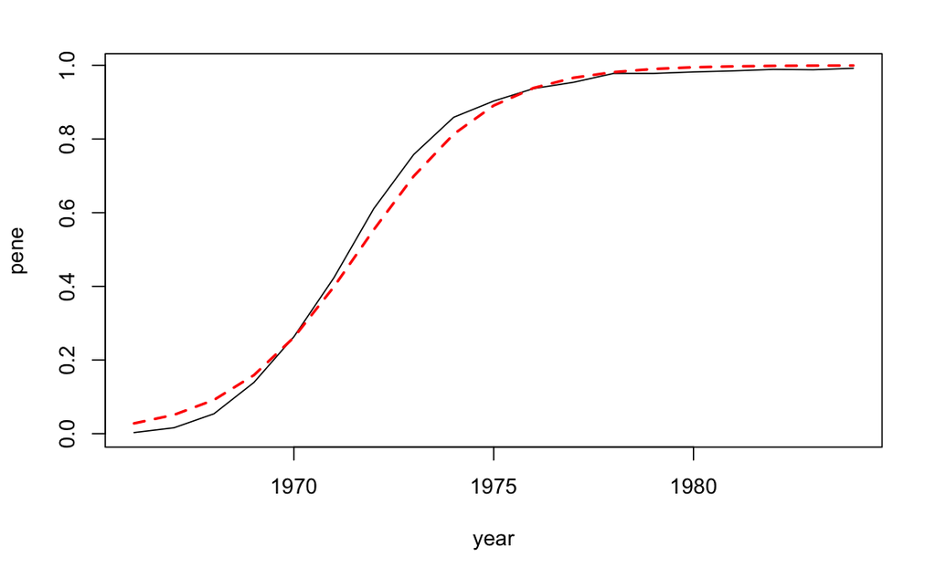

```r
# 普及率.txtをデータフレームに格納
data <- read.delim(
  "data/普及率.txt",
  header=TRUE,         # 1行目は列名
  fileEncoding="UTF-8" # 文字コードの変換方式
)

# データフレームの各列のデータをベクトルに格納
year <- c(data[,1]) # 年度
pene <- c(data[,2]) # 普及率

# ロジスティック回帰分析を行う
# family=binomialでロジット関数を指定
model <- glm(pene~year,
             family=binomial)
# 実測値の散布図を描く
plot(year, pene,
     type="l") # ラインで描画

# 予測値を曲線で描画する
lines(year,          # x座標は年代
      fitted(model), # y座標は予測値
      lty=2,         # 点線で描画
      col="red",     # 色を赤にする
      lwd=2)         # 点線の太さ
```

```r
# 実測値と予測値をデータフレームに結合
predict <- cbind(data,
             fitted(model))
```

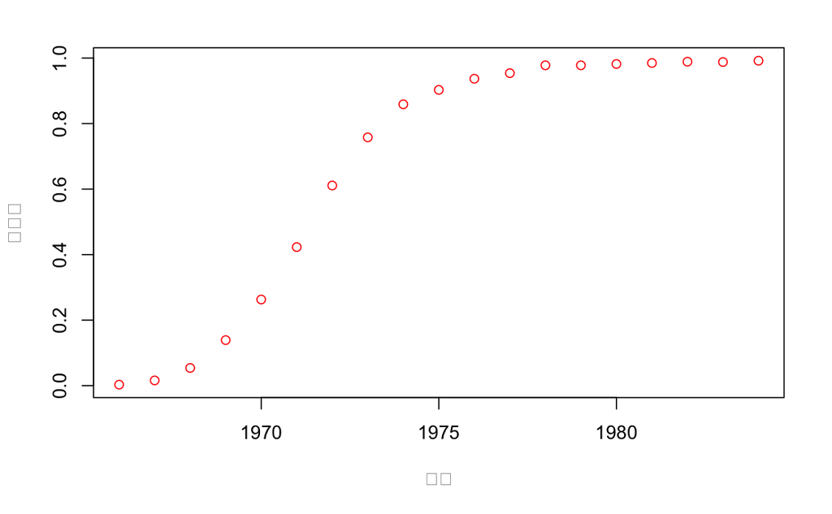

```r
# 普及率.txtをデータフレームに格納
data <- read.delim(
  "data/普及率.txt",
  header=TRUE,         # 1行目は列名
  fileEncoding="UTF-8" # 文字コードの変換方式
)

# データフレームの各列のデータをベクトルに格納
year <- c(data[,1]) # 年度
pene <- c(data[,2]) # 普及率

# 散布図を描く
plot(data, col="red")
```

```r
# 非線形回帰分析を実行
model <- nls(
  pene ~ K/(1 + b*exp(c*year)), # モデル式
  start=c(K=1, b=1, c=-1),      # 係数の初期値を設定
  trace=TRUE                    # 計算過程を出力
  )
```

```
Error in nlsModel(formula, mf, start, wts, scaleOffset = scOff, nDcentral = nDcntr) :
  singular gradient matrix at initial parameter estimates
```

```r
# 普及率.txtをデータフレームに格納
data <- read.delim(
  "data/普及率.txt",
  header=TRUE,         # 1行目は列名
  fileEncoding="UTF-8" # 文字コードの変換方式
)

# データフレームの各列のデータをベクトルに格納
year <- c(data[,1]) # 年度
pene <- c(data[,2]) # 普及率

# SSlogis()をモデル式に使用して非線形回帰分析
model_ss <- nls(
  pene ~ SSlogis(year, Asym, xmid, scal)
)
# 分析結果を表示
summary(model_ss)
```

```
Formula: pene ~ SSlogis(year, Asym, xmid, scal)

Parameters:
      Estimate Std. Error  t value Pr(>|t|)
Asym 9.806e-01  3.840e-03   255.40   <2e-16 ***
xmid 1.971e+03  3.533e-02 55791.85   <2e-16 ***
scal 1.324e+00  3.055e-02    43.35   <2e-16 ***
---
Signif. codes:  0 ‘***’ 0.001 ‘**’ 0.01 ‘*’ 0.05 ‘.’ 0.1 ‘ ’ 1

Residual standard error: 0.01104 on 16 degrees of freedom

Number of iterations to convergence: 0
Achieved convergence tolerance: 2.251e-07
```

```r
# 予測値を結合したデータフレームを作成
predict_ss <- cbind(data,
                    fitted(model_ss))
```

- `sigmoid.R`

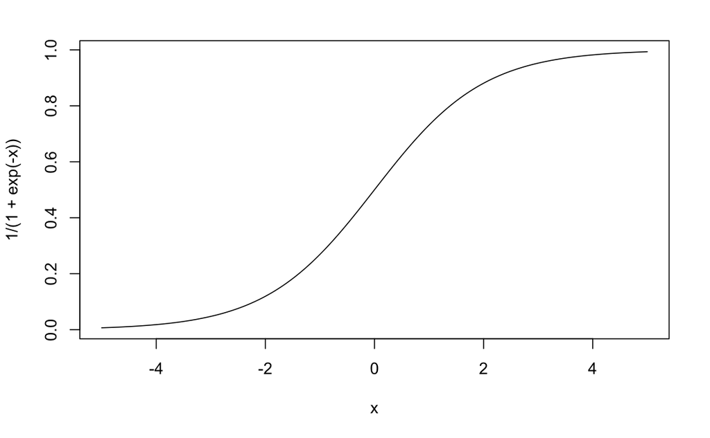

```r
x <- seq(from=-5,to=5,length=200)
plot(x,1/(1+exp(-x)),type="l")
```

**PROBLEM !!!**

## 9.5 モルモットの実験データから、ビタミンCを何で与えたかを予測する

### 9.5.1 ロジット関数を用いた二値分類

#### 9.5.1.1 ロジット関数

### 9.5.2 ロジット関数で二値分類を行う

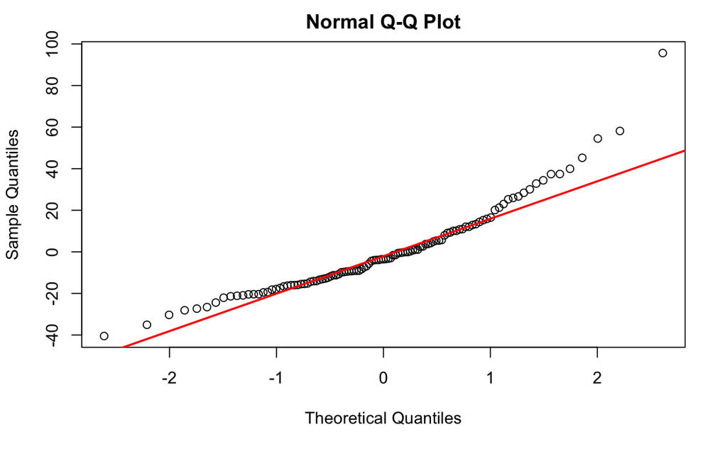

```r
# airqualityを読み込み、欠損値がある行を削除してデータフレームに格納
airquality <- na.omit(airquality)

# 線形重回帰分析を実行
model_lm <- lm(
  Ozone ~ Solar.R + Wind + Temp,
  data=airquality
  )

# 残差の散布図を描画
qqnorm(
  resid(model_lm) ) # 残差を抽出

# 散布図に上下四分位点を結ぶ直線を描画
qqline(
  resid(model_lm), # 残差を抽出
  lwd=2,
  col="red")
```

```r
# 一般化線形モデルに正規分布を使う
model_normal <- glm(
  Ozone ~ Solar.R + Wind + Temp,
  data=airquality,
  family = gaussian # 正規分布を使用
  )

# 一般化線形モデルにガンマ分布を使う
model_gamma <- glm(
  Ozone ~ Solar.R + Wind + Temp,
  data=airquality,
  family = Gamma # ガンマ分布を使用
)

# 実測値に正規分布モデルとガンマ分布モデルの予測値を結合した表を作成
pred <- cbind(airquality[,1],
              fitted(model_normal), # 正規分布を使用したモデルの予測値
              fitted(model_gamma))  # ガンマ分布を使用したモデルの予測値

# 正規分布を使用したモデルのAIC値
AIC(model_normal)
```

```
[1] 998.7171
```

```r
# ガンマ分布を使用したモデルのAIC値
AIC(model_gamma)
```

```
[1] 939.8778
```

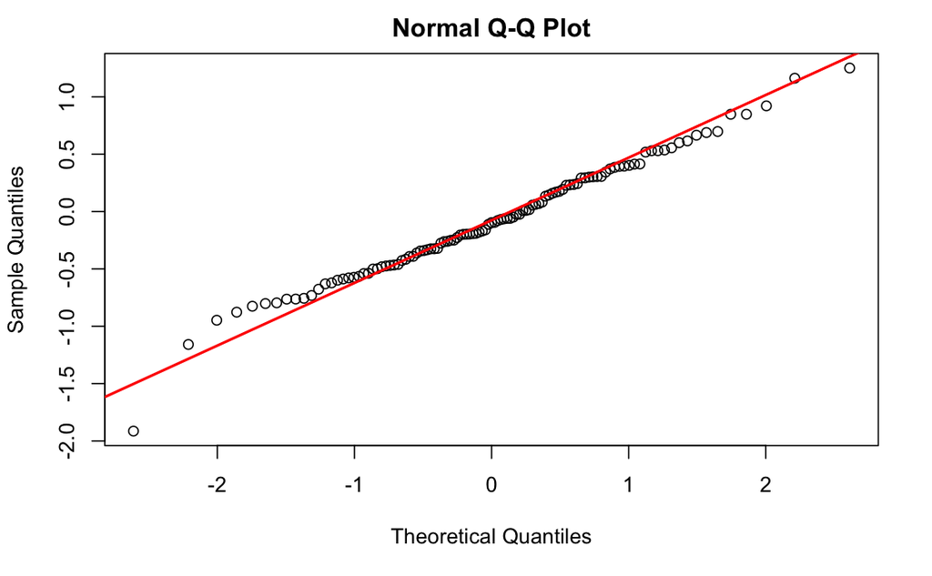

```r
# ガンマ分布を使用したモデルにおける残差の散布図を描画
qqnorm(resid(model_gamma))
# 散布図に上下四分位点を結ぶ直線を描画
qqline(resid(model_gamma),lwd=2,col="red")
```

```r
# ToothGrowthをデータフレームに格納
data <- data.frame(ToothGrowth)

# ロジット関数を適用したモデル
# 投与方法(supp)を目的変数、
# 歯の長(len)と投与量(dose)を説明変数にする
model<- glm(supp ~ len + dose,
            family=binomial, # ロジット関数を指定
            data=data)       # データフレームを指定

# 予測値を四捨五入して0と1に分類
predict <- round(fitted(model))

# データフレームを作成
result <- data.frame(data[,2], predict)

# クロス集計表を作成
table(data[,2], predict)
```

```
    predict
      0  1
  OJ 17 13
  VC  7 23
```

### Tips ロジット関数の逆関数はシグモイド関数

# 10 クラスター分析

## 10.1 バラバラに散らばるデータを統計的に整理しよう

#### 10.1.0.1 （階層的クラスター分析）

### 10.1.1 データを統計的な考え方でグループ分けするのがクラスター分析

#### 10.1.1.1 階層的クラスター分析

#### 10.1.1.2 階層的クラスター分析のプロセス

#### 10.1.1.3 データ行列を作って距離行列を作る（分析のプロセス①～②）

#### 10.1.1.4 距離行列からコーフェン行列を作る（分析のプロセス③）

### 10.1.2 階層的クラスター分析で他の方法を試してみる

#### 10.1.2.1 クラスタリングの過程を見てみる

```r
# "学習時間.txt"をデータフレームに格納
data <- read.delim(
  "data/学習時間.txt",
  header=TRUE, # 1行目は列名
  row.names=1, # 1列目は行名
  fileEncoding="UTF-8" # 文字コードの変換方式
)

# データフレームの1行目～7行目のデータを(7行,5列)の行列にする
time <- matrix(c(data[1,],
                 data[2,],
                 data[3,],
                 data[4,],
                 data[5,],
                 data[6,],
                 data[7,]),
               7, 5, byrow = TRUE)  # (7行,5列)を指定

# 列名を設定
colnames(time) <- c(colnames(data))
# 行名を設定
rownames(time) <- c(rownames(data))
# 行列を出力
time
```

```
     国語 英語 世界史 数学 生物
芥川 35   40   50     81   91
直木 80   85   90     57   70
夏目 50   45   55     41   60
太宰 45   55   60     78   85
川端 80   75   85     55   65
志賀 87   92   95     90   85
村上 67   46   50     89   90
```

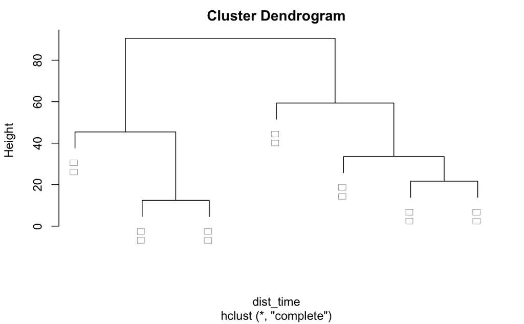

```r
# ユークリッド距離を求める
dist_time <- dist(time)
# デフォルトの最遠隣法でクラスター分析を実行
comp_time <- hclust(dist_time)
# 樹形図を作成
plot(comp_time)
```

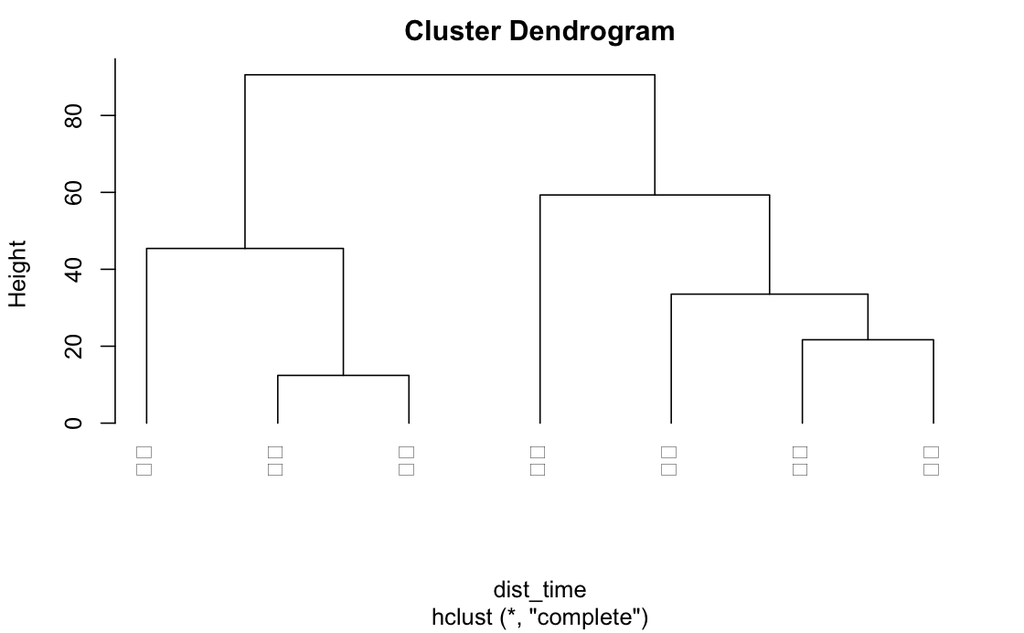

```r
# 樹形図を作成(葉の高さを揃える)
plot(comp_time, hang=-1)
```

```r
# クラスタリングの過程を示す行列を出力
comp_time$merge
```

```
     [,1] [,2]
[1,]   -2   -5
[2,]   -1   -4
[3,]   -7    2
[4,]   -6    1
[5,]   -3    3
[6,]    4    5
```

```r
# クラスターの枝の高さを出力
comp_time$height
```

```
[1] 12.40967 21.67948 33.54102 45.42026 59.32116 90.57593
```

```r
# コーフェン行列を取得
cophenetic(comp_time)
```

```
         芥川     直木     夏目     太宰     川端     志賀
直木 90.57593
夏目 59.32116 90.57593
太宰 21.67948 90.57593 59.32116
川端 90.57593 12.40967 90.57593 90.57593
志賀 90.57593 45.42026 90.57593 90.57593 45.42026
村上 33.54102 90.57593 59.32116 33.54102 90.57593 90.57593
```

```r
# 樹形図の個体番号を取得
comp_time$order
```

```
[1] 6 2 5 3 7 1 4
```

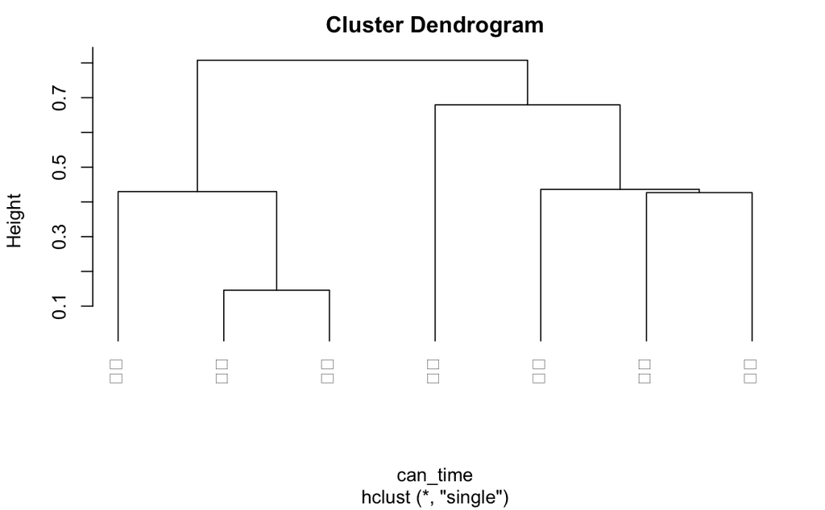

```r
# キャンベラ距離を求める
can_time <- dist(time,"canberra")
# 最近隣法で分析
single_time <- hclust(can_time, method="single")
# 樹形図を作成(葉の高さを揃える)
plot(single_time, hang=-1)
```